# Análisis químico-sensorial de la calidad del whisky chileno

### 2.3.7 Componentes principales sensoriales y atípicos multivariados

** 09_biplot_pca_sensorial_cata_alexandra_260603 **

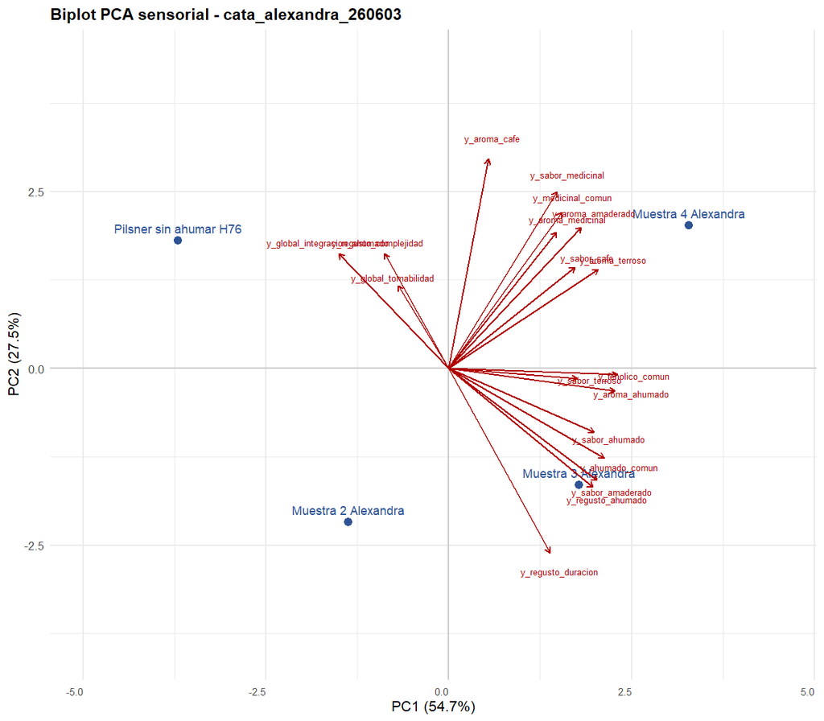

** 09_biplot_pca_sensorial_cata_septiembre_2024 **

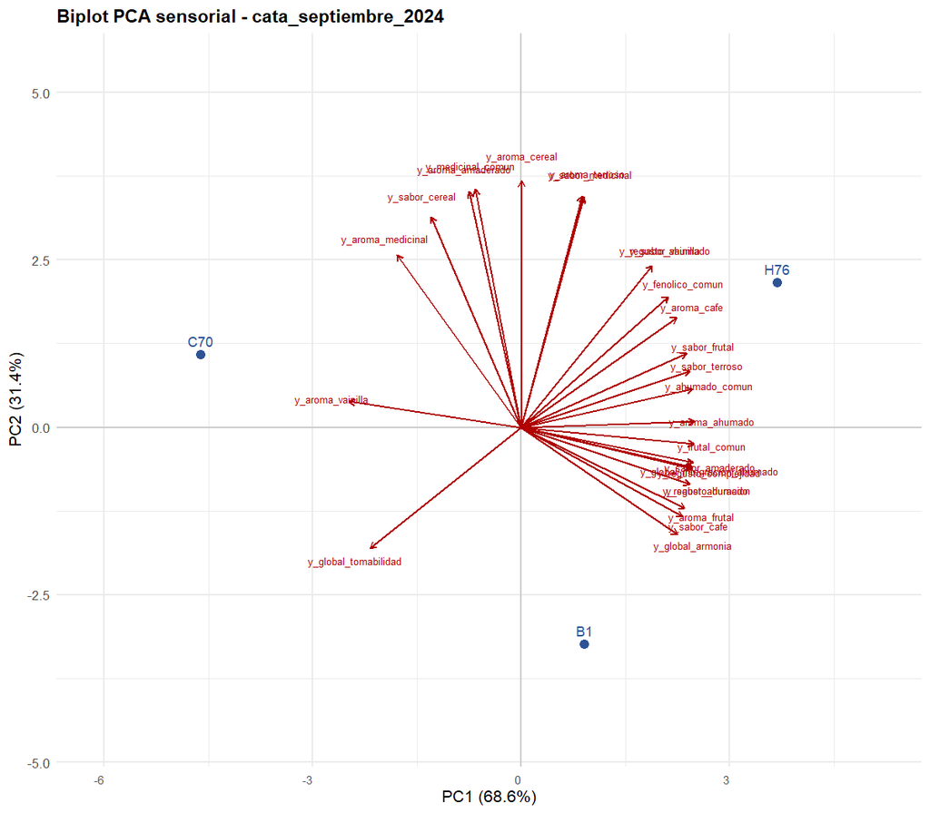

** 09_biplot_pca_sensorial_cata_social_enero_2025 **

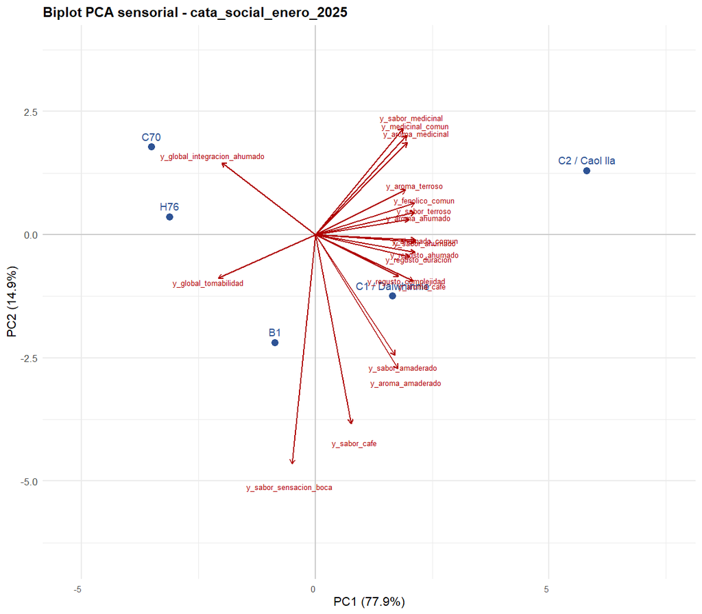

** 09_biplot_pca_sensorial_panel_noviembre **

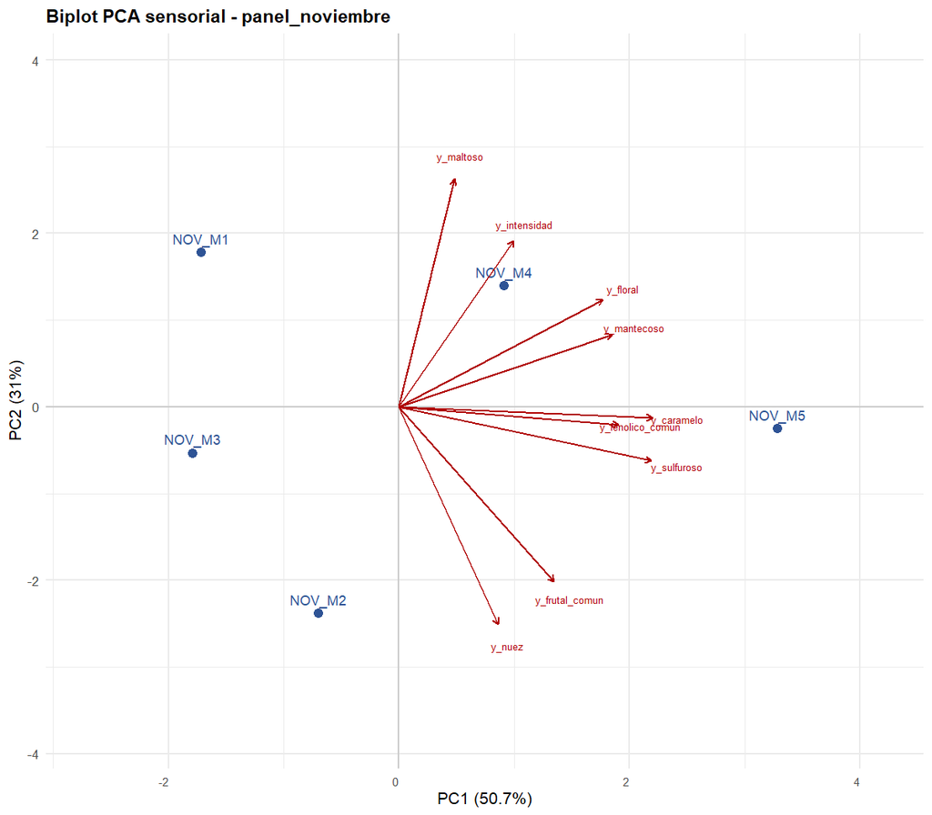

** 09_biplot_pca_sensorial_sensorial_cepas_ju **

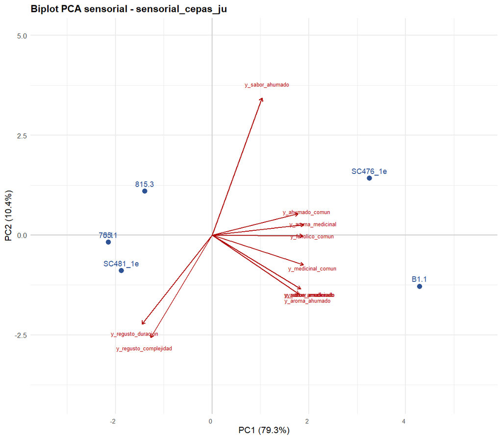

** 10_distancia_t2_q_cata_alexandra_260603 **

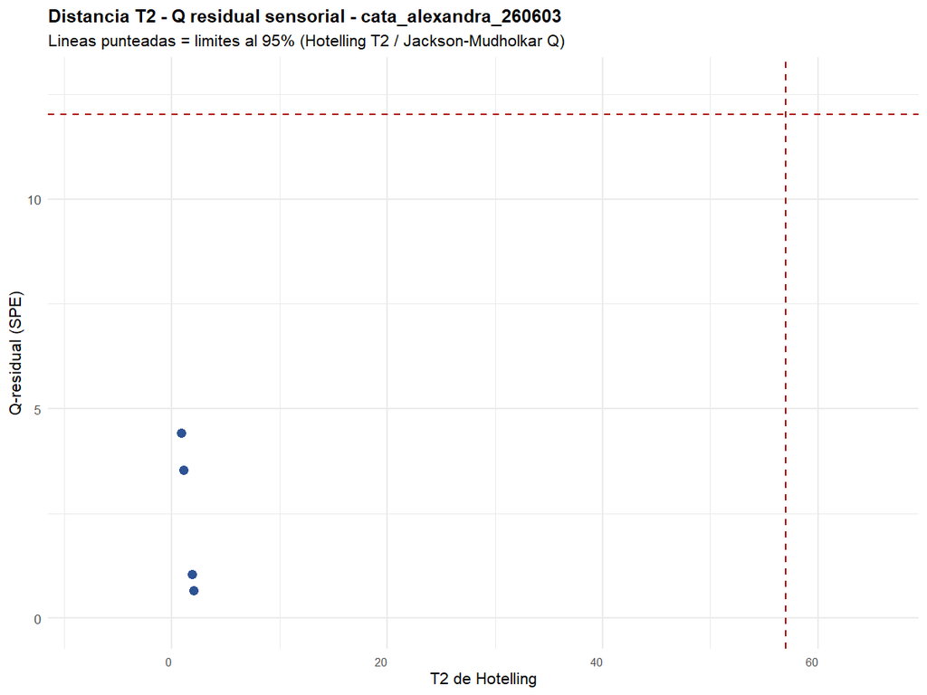

** 10_distancia_t2_q_cata_septiembre_2024 **

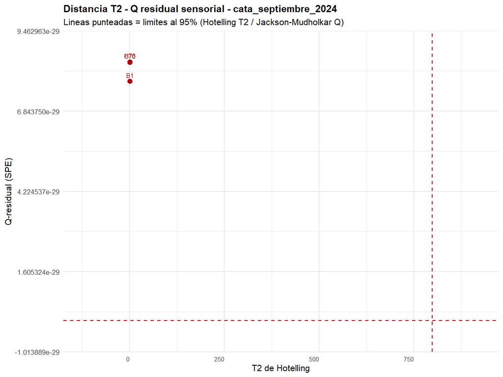

** 10_distancia_t2_q_cata_social_enero_2025 **

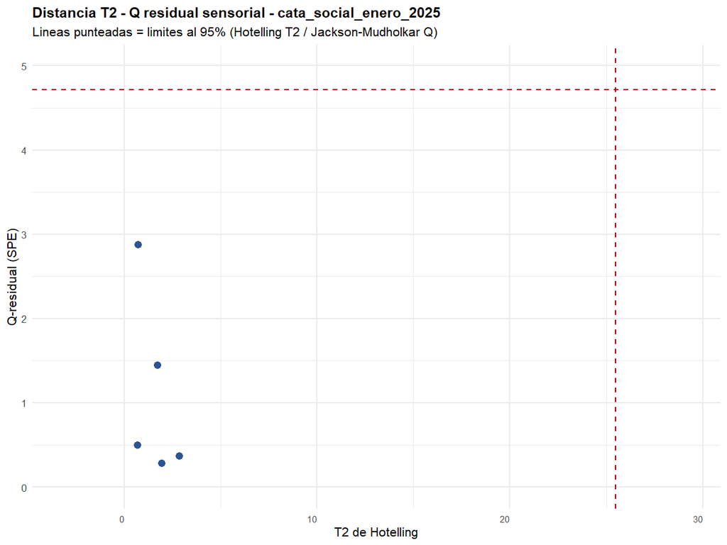

** 10_distancia_t2_q_panel_noviembre **

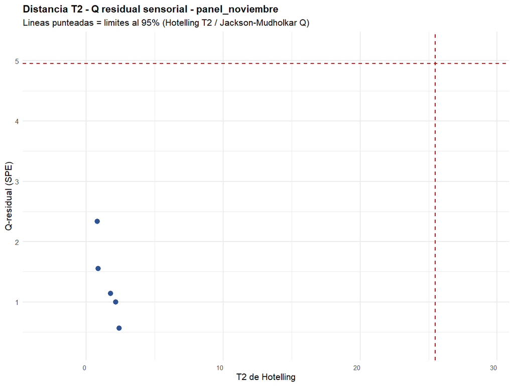

** 10_distancia_t2_q_sensorial_cepas_ju **

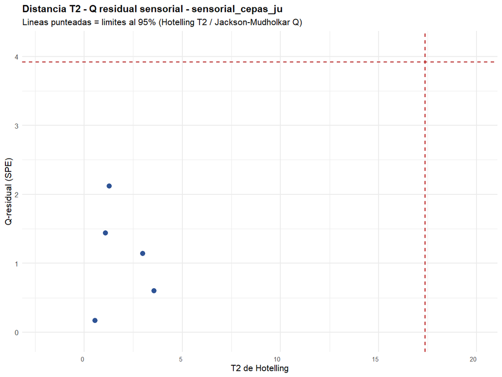

| grupo_pca | muestra_cata | identificador_sensorial | t2_hotelling | excede_t2 | q_residual | excede_q |
| --- | --- | --- | --- | --- | --- | --- |
| cata_septiembre_2024 | Muestra 1 | C70 | 1.333333 | FALSE | 0 | TRUE |
| cata_septiembre_2024 | Muestra 2 | B1 | 1.333333 | FALSE | 0 | TRUE |
| cata_septiembre_2024 | Muestra 3 | H76 | 1.333333 | FALSE | 0 | TRUE |

## 2.4 Cruce químico-sensorial

Esta sección cruza, de forma exploratoria y previa al modelamiento formal, los predictores químicos con los targets sensoriales, usando correlación de Pearson por pares (`pairwise.complete.obs`) y exigiendo al menos 5 pares con dato disponible para reportar un valor. Se usa el escenario `M_pura` (34 unidades con química real y cata real agregada), y no reemplaza el diagnóstico de colinealidad ni los modelos supervisados de la Parte 3 — es solo una primera mirada a qué variables podrían estar asociadas antes de entrar a esos análisis formales.

| indicador | valor |
| --- | --- |
| Escenario | M_pura (quimica real + cata real agregada, evidencia principal) |
| Unidades analiticas (filas) | 34 |
| Predictores quimicos (x_*) | 32 |
| Targets sensoriales (y_*) | 34 |
| Targets principales | y_frutal_comun, y_fenolico_comun, y_ahumado_comun, y_medicinal_comun |
| Uso de este analisis | Vista exploratoria previa (EDA), no reemplaza el diagnostico de colinealidad ni el modelamiento supervisado. |
| Advertencia metodologica | El VIF global no aplica por baja superposicion entre tecnicas analiticas (ver colinealidad_modelamiento.xlsx); esta hoja usa correlacion pareada simple, con n variable por par segun el bloque quimico … |

La tabla resume el escenario usado, los 32 predictores químicos evaluados y los 4 targets sensoriales principales considerados (`y_frutal_comun`, `y_fenolico_comun`, `y_ahumado_comun`, `y_medicinal_comun`).

### 2.4.1 Heatmap general: predictores químicos vs. targets principales

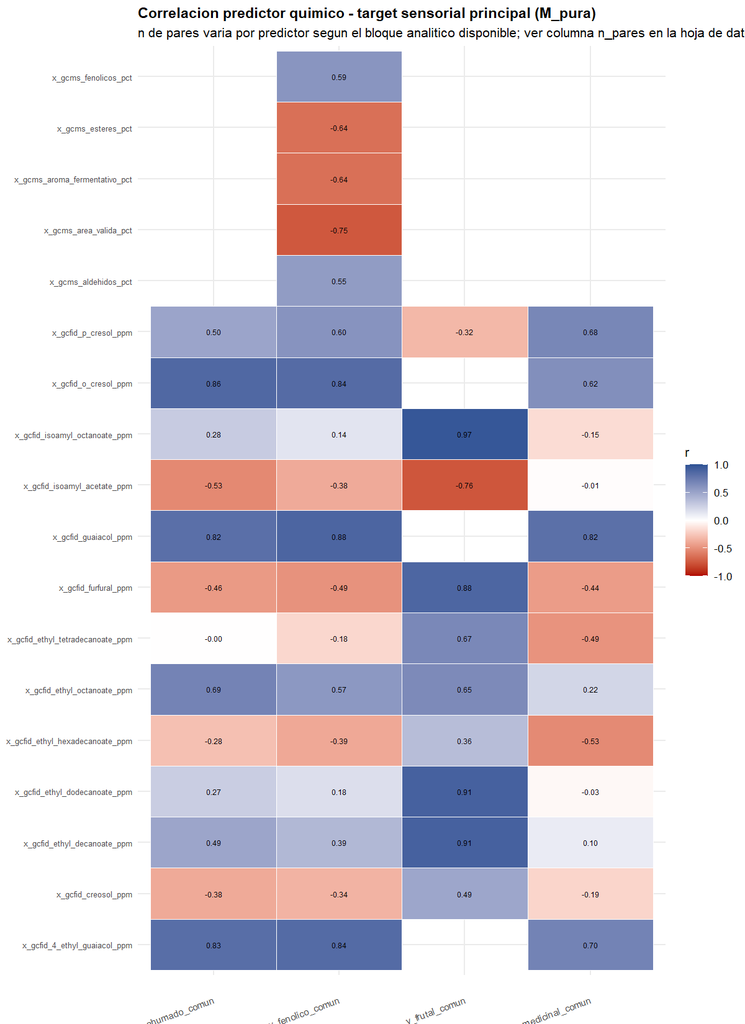

### 2.4.2 Heatmaps por bloque analítico

Como los bloques químicos no comparten unidades analíticas entre sí (ver completitud, sección 2.2.1), conviene además mirar cada bloque por separado en vez de solo el heatmap combinado.

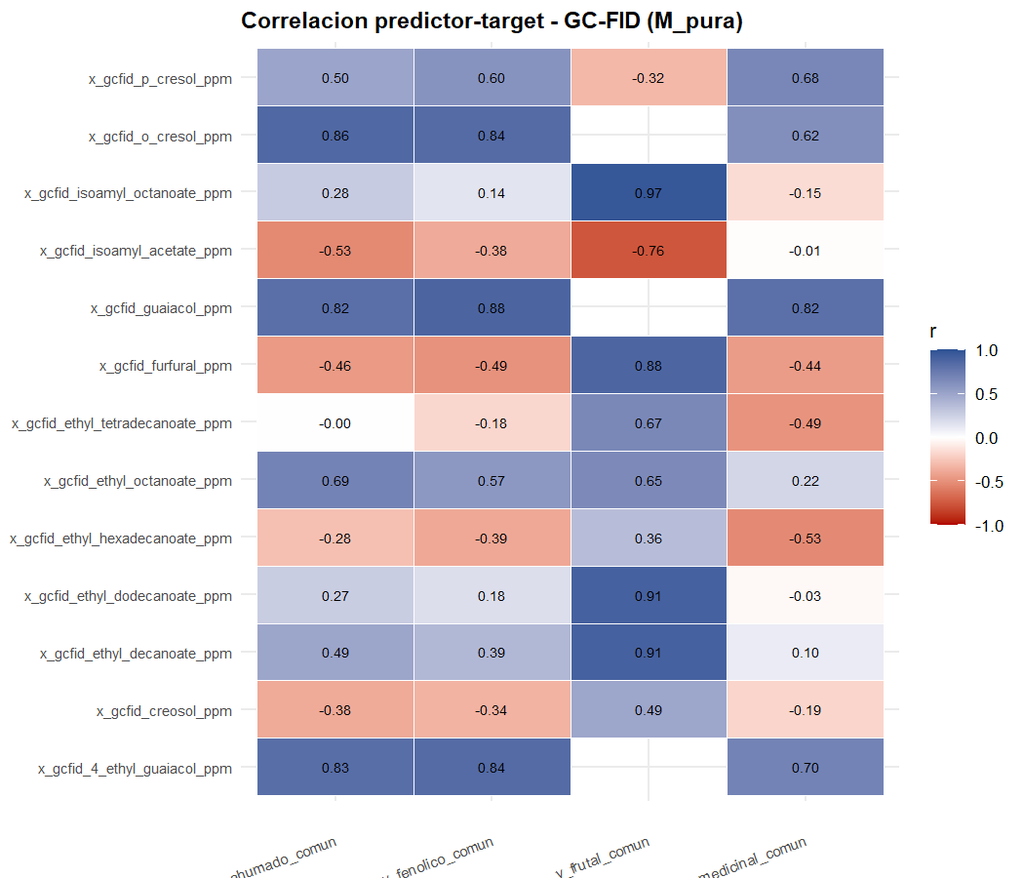

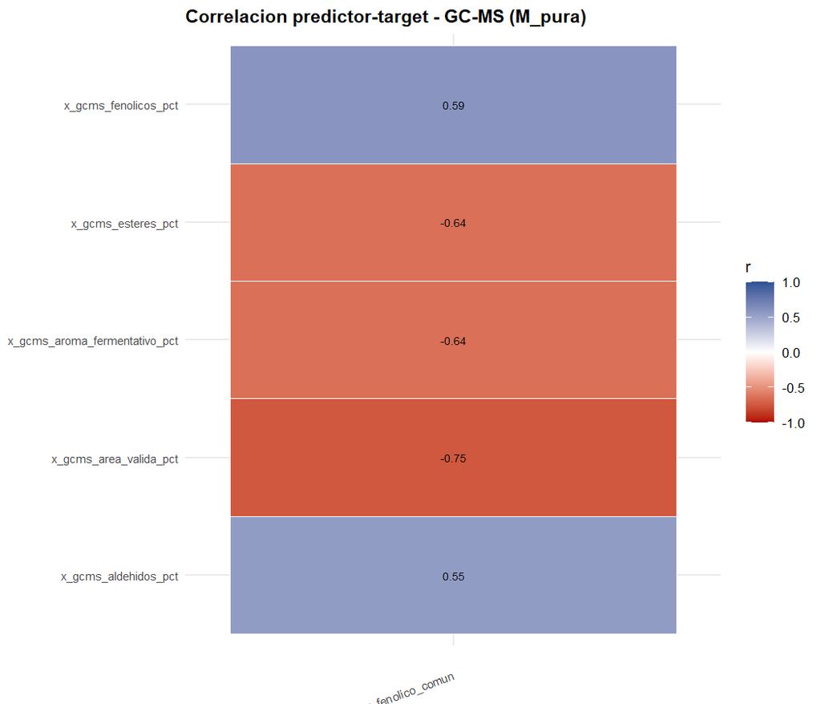

El bloque GC-MS solo alcanza el mínimo de pares frente a `y_fenolico_comun` (5 pares), por lo que es el único target con celda calculada para este bloque. El área válida y los ésteres/aroma fermentativo correlacionan negativamente con el fenólico (r ≈ -0.6 a -0.75), mientras que fenólicos y aldehídos correlacionan positivamente (r ≈ 0.55–0.59). Dado que son solo 5 pares, esta lectura es referencial y no debe compararse en fuerza con los resultados de GC-FID, que tienen bastante más respaldo muestral.

El bloque **JU** no genera un heatmap propio en este cruce: por definición, `M_pura` excluye la cata individual JU (ver Matriz 1 en la Parte 1), así que sus predictores fermentativos casi no se solapan con unidades que tengan cata real y no llegan al mínimo de 5 pares frente a ningún target. Para ver JU cruzado con sensorial hay que usar el escenario de sensibilidad `M_cata_individual` (Matriz 5, Parte 1), no este cruce exploratorio.

### 2.4.3 Pares con correlación alta (|r| ≥ 0.5)

| predictor | target | n_pares | correlacion | abs_correlacion |
| --- | --- | --- | --- | --- |
| x_gcfid_ethyl_dodecanoate_ppm | y_global_armonia | 9 | 0.9963613 | 0.9963613 |
| x_gcfid_ethyl_tetradecanoate_ppm | y_sabor_cereal | 9 | -0.9927572 | 0.9927572 |
| x_gcfid_ethyl_dodecanoate_ppm | y_aroma_frutal | 9 | 0.9849455 | 0.9849455 |
| x_gcfid_ethyl_decanoate_ppm | y_sabor_frutal | 9 | 0.9832958 | 0.9832958 |
| x_gcfid_furfural_ppm | y_sabor_frutal | 9 | 0.9808440 | 0.9808440 |
| x_gcfid_isoamyl_octanoate_ppm | y_aroma_frutal | 9 | 0.9783320 | 0.9783320 |
| x_gcfid_isoamyl_octanoate_ppm | y_aroma_vainilla | 9 | -0.9766505 | 0.9766505 |
| x_gcfid_isoamyl_octanoate_ppm | y_frutal_comun | 9 | 0.9715324 | 0.9715324 |
| x_gcfid_ethyl_hexadecanoate_ppm | y_sabor_cereal | 9 | -0.9690804 | 0.9690804 |
| x_gcfid_isoamyl_acetate_ppm | y_sabor_cereal | 9 | 0.9679891 | 0.9679891 |
| x_gcfid_isoamyl_octanoate_ppm | y_global_armonia | 9 | 0.9597624 | 0.9597624 |
| x_gcfid_ethyl_hexadecanoate_ppm | y_aroma_cereal | 9 | -0.9540524 | 0.9540524 |
| x_gcfid_ethyl_octanoate_ppm | y_sabor_cereal | 9 | -0.9492496 | 0.9492496 |
| x_gcfid_isoamyl_acetate_ppm | y_global_armonia | 9 | -0.9439342 | 0.9439342 |
| x_gcfid_furfural_ppm | y_sabor_vainilla | 9 | 0.9379441 | 0.9379441 |
| x_gcfid_ethyl_dodecanoate_ppm | y_aroma_vainilla | 9 | -0.9234281 | 0.9234281 |
| x_gcfid_ethyl_decanoate_ppm | y_sabor_vainilla | 9 | 0.9103115 | 0.9103115 |
| x_gcfid_ethyl_decanoate_ppm | y_frutal_comun | 9 | 0.9088917 | 0.9088917 |
| x_gcfid_ethyl_dodecanoate_ppm | y_frutal_comun | 9 | 0.9088533 | 0.9088533 |
| x_gcfid_o_cresol_ppm | y_sabor_ahumado | 26 | 0.9010245 | 0.9010245 |
| x_gcfid_isoamyl_acetate_ppm | y_aroma_frutal | 9 | -0.9007599 | 0.9007599 |
| x_gcfid_ethyl_octanoate_ppm | y_sabor_amaderado | 26 | 0.8967265 | 0.8967265 |
| x_gcfid_ethyl_tetradecanoate_ppm | y_global_armonia | 9 | 0.8952580 | 0.8952580 |
| x_gcfid_ethyl_decanoate_ppm | y_aroma_vainilla | 9 | -0.8943567 | 0.8943567 |
| x_gcfid_guaiacol_ppm | y_fenolico_comun | 26 | 0.8809552 | 0.8809552 |
| x_gcfid_furfural_ppm | y_frutal_comun | 9 | 0.8793002 | 0.8793002 |
| x_gcfid_ethyl_octanoate_ppm | y_global_armonia | 9 | 0.8663784 | 0.8663784 |
| x_gcfid_o_cresol_ppm | y_ahumado_comun | 26 | 0.8641168 | 0.8641168 |
| x_gcfid_furfural_ppm | y_aroma_vainilla | 9 | -0.8622242 | 0.8622242 |
| x_gcfid_ethyl_dodecanoate_ppm | y_sabor_cereal | 9 | -0.8605346 | 0.8605346 |

[output cut: 99 more lines]

# 3 - MODELAMIENTO

## 3.1 Objetivo de esta parte

Los escenarios evaluados son:

| Escenario | Filas | Rol |
| --- | --- | --- |
| `M_pura` | 34 | Principal — evidencia central de resultados |
| `M_cata_individual` | 52 | Sensibilidad — pura + cata individual JU agregada |
| `M_expandida_evaluador` | 685 | Complementario por evaluador (no independiente) |
| `M_ia_exploratoria` | 42 | Sintético exploratorio (no reemplaza cata real); 42 filas químicas con estimación IA utilizable, provenientes de 24 muestras físicas únicas |

Antes de mostrar los resultados de cada etapa, las siguientes dos secciones explican qué modelos se probaron y cómo se compensa, metodológicamente, tener tan pocas muestras con cata real.

## 3.2 Modelos que se van a utilizar

Se prueban dos modelos base (piso mínimo de comparación) y seis modelos candidatos, todos evaluados sobre los mismos escenarios y targets:

**Modelos base:**

- **Media de entrenamiento**: predice siempre el promedio del target visto en entrenamiento, sin usar ninguna variable química. Es el piso absoluto: cualquier modelo candidato que no le gane no está aportando información real.
- **Regresión lineal reducida**: regresión lineal simple con hasta 3 predictores, elegidos por correlación con el target *dentro de cada fold* (para no filtrar información de test hacia el entrenamiento). Es un piso más exigente que la media, porque sí usa química, pero de forma muy simple.

**Modelos candidatos (small data):**

- **Ridge, Lasso y Elastic Net**: regresiones lineales regularizadas, que penalizan coeficientes grandes para controlar el sobreajuste cuando hay más predictores correlacionados que observaciones independientes — justamente el escenario de colinealidad que se documenta más abajo. Lasso y Elastic Net además pueden llevar coeficientes a cero, funcionando como selección de variables automática.
- **PLS (mínimos cuadrados parciales)**: en vez de usar los predictores originales, construye combinaciones lineales de ellos que maximizan su relación con el target, reduciendo la dimensionalidad antes de ajustar. Útil cuando hay muchos predictores correlacionados entre sí, como ocurre en los grupos GC-FID y GC-MS.
- **Random Forest restringido** (`ranger`) y **Gradient Boosting restringido** (`gbm`): modelos de árboles con su complejidad limitada a propósito (profundidad y número de árboles reducidos, `mtry` acotado) — un Random Forest o Gradient Boosting sin restricciones prácticamente memoriza el set de entrenamiento cuando hay 30-50 filas, así que se restringen para que generalicen en vez de sobreajustar.

Todos se ajustan con validación cruzada y se comparan primero con una pasada simple (sección “Modelos candidatos”) y luego con el bootstrap agrupado, que es el que finalmente determina el modelo recomendado por escenario.

## 3.3 Manejo del tamaño de muestra pequeño

En este estudio no se usan técnicas de aumento de datos sintéticas tipo SMOTE (pensadas para clasificación desbalanceada, no aplican a un target continuo con 34 muestras). En su lugar, el tamaño de muestra utilizable se maneja con tres estrategias complementarias:

1. **Escenarios adicionales que suman filas sin inventar química nueva.** `M_expandida_evaluador` no promedia los puntajes de los catadores por muestra, sino que deja una fila por evaluador (685 filas sobre las mismas 34 muestras químicas); `M_cata_individual` agrega las 18 filas de la cata individual JU a las 34 de la matriz pura. Ambos aportan más señal de entrenamiento, pero se validan agrupando por unidad química (ver punto 2) para no contar la misma muestra química varias veces como si fuera evidencia independiente.
2. **Validación por bootstrap agrupado** (sección más abajo): 100 iteraciones de remuestreo con reemplazo, agrupando por unidad analítica, de forma que todas las filas de una misma muestra química caen siempre juntas en entrenamiento o en prueba, nunca repartidas entre ambos. Esto evita una fuga de información que sobreestimaría el desempeño, y es la técnica central para exprimir al máximo los pocos datos disponibles sin inflar artificialmente los resultados.
3. **Regularización y restricción de modelos** (Ridge/Lasso/Elastic Net, árboles restringidos): con tan pocas observaciones no hay margen para dejar un conjunto de validación completamente aparte sin sacrificar datos de entrenamiento, así que el control de sobreajuste se hace principalmente dentro del propio modelo (penalización de coeficientes, profundidad limitada) en vez de con un split de datos más grande.

Con este marco definido, las siguientes secciones muestran los resultados de cada etapa.

## 3.4 Diagnóstico de viabilidad por escenario

Antes de ajustar cualquier modelo se revisa una heurística de viabilidad — no un cálculo formal de un modelo específico, sino un chequeo rápido de EDA para *small data*: **grados de libertad aproximados = filas modelables (con dato no vacío en el target) − predictores usables** (predictores con al menos 3 valores, al menos 2 valores distintos y desviación estándar mayor que cero). Un valor negativo significa que hay más predictores que datos para estimarlos, y el ajuste no es confiable por más regularización que se use; valores por debajo de 15 quedan marcados como “alerta” y por debajo de 5 (u observaciones totales menores a 8) como “crítico”.

| escenario | target | n_filas_totales | n_filas_modelables | n_predictores_usables | grados_libertad_aprox | severidad_small_data | apto_modelamiento_supervisado |
| --- | --- | --- | --- | --- | --- | --- | --- |
| M_cata_individual | y_ahumado_comun | 52 | 48 | 26 | 22 | aceptable_para_small_data | TRUE |
| M_cata_individual | y_fenolico_comun | 52 | 52 | 26 | 26 | aceptable_para_small_data | TRUE |
| M_cata_individual | y_frutal_comun | 52 | 13 | 26 | -13 | critico_gl_insuficiente | TRUE |
| M_cata_individual | y_medicinal_comun | 52 | 48 | 26 | 22 | aceptable_para_small_data | TRUE |
| M_expandida_evaluador | y_ahumado_comun | 685 | 645 | 13 | 632 | aceptable_para_small_data | TRUE |
| M_expandida_evaluador | y_fenolico_comun | 685 | 685 | 13 | 672 | aceptable_para_small_data | TRUE |
| M_expandida_evaluador | y_frutal_comun | 685 | 118 | 13 | 105 | aceptable_para_small_data | TRUE |
| M_expandida_evaluador | y_medicinal_comun | 685 | 645 | 13 | 632 | aceptable_para_small_data | TRUE |
| M_ia_exploratoria | y_ahumado_comun | 42 | 42 | 5 | 37 | aceptable_para_small_data | TRUE |
| M_ia_exploratoria | y_fenolico_comun | 42 | 42 | 5 | 37 | aceptable_para_small_data | TRUE |
| M_ia_exploratoria | y_frutal_comun | 42 | 6 | 5 | 1 | critico_muy_pocos_datos | TRUE |
| M_ia_exploratoria | y_medicinal_comun | 42 | 39 | 5 | 34 | aceptable_para_small_data | TRUE |
| M_pura | y_ahumado_comun | 34 | 30 | 13 | 17 | aceptable_para_small_data | TRUE |
| M_pura | y_fenolico_comun | 34 | 34 | 13 | 21 | aceptable_para_small_data | TRUE |
| M_pura | y_frutal_comun | 34 | 13 | 13 | 0 | critico_gl_insuficiente | TRUE |
| M_pura | y_medicinal_comun | 34 | 30 | 13 | 17 | aceptable_para_small_data | TRUE |
| M_quimica | NA | 63 | NA | 10 | NA | sin_target | FALSE |
| M_sensorial | y_ahumado_comun | 37 | 27 | 0 | 27 | aceptable_para_small_data | FALSE |
| M_sensorial | y_fenolico_comun | 37 | 37 | 0 | 37 | aceptable_para_small_data | FALSE |
| M_sensorial | y_frutal_comun | 37 | 10 | 0 | 10 | alerta_gl_ajustado | FALSE |
| M_sensorial | y_medicinal_comun | 37 | 27 | 0 | 27 | aceptable_para_small_data | FALSE |

** 01_grados_libertad_por_escenario **

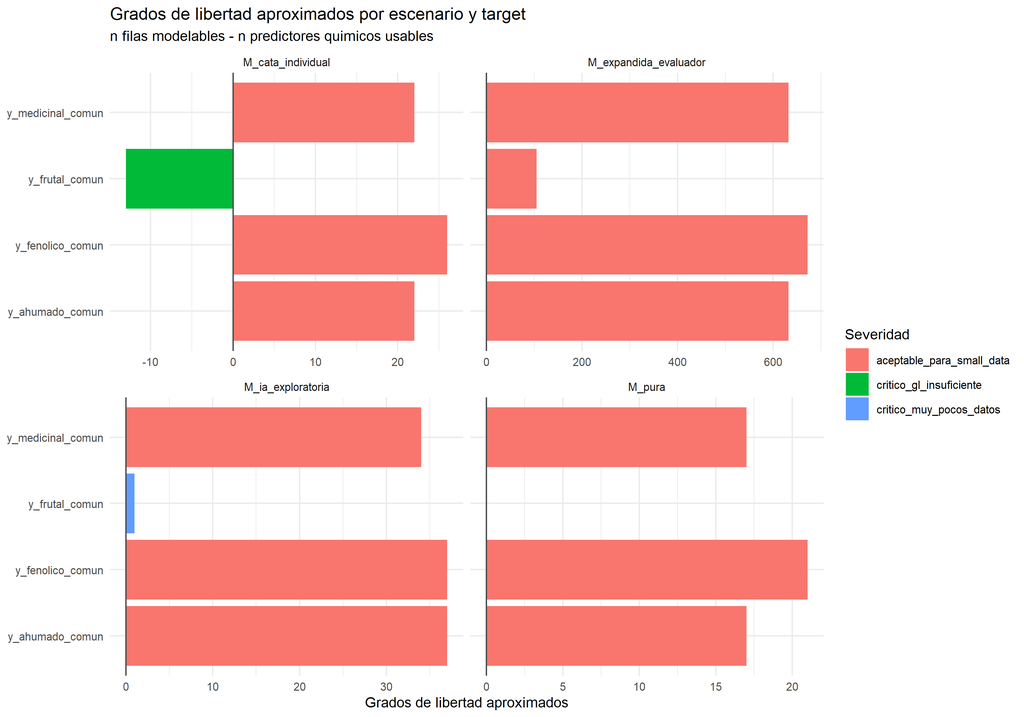

## 3.5 Colinealidad de predictores

Dado que los predictores provienen de técnicas analíticas no solapadas (GC-MS, GC-FID, Folin, JU fermentativo), no se aplica un VIF global; se usa correlación pareada de Pearson como diagnóstico principal, complementado con VIF por bloque y VIF del modelo base reducido.

| escenario | predictor | n_filas | n_no_na | pct_no_na | n_distintos | desviacion_estandar | usable_correlacion | motivo |
| --- | --- | --- | --- | --- | --- | --- | --- | --- |
| M_pura | x_gcfid_ethyl_octanoate_ppm | 34 | 26 | 76.47 | 17 | 27.481312 | TRUE | usable |
| M_pura | x_gcfid_isoamyl_acetate_ppm | 34 | 26 | 76.47 | 17 | 1.091867 | TRUE | usable |
| M_pura | x_gcfid_furfural_ppm | 34 | 24 | 70.59 | 15 | 0.497424 | TRUE | usable |
| M_pura | x_gcfid_o_cresol_ppm | 34 | 26 | 76.47 | 9 | 0.027408 | TRUE | usable |
| M_pura | x_gcfid_p_cresol_ppm | 34 | 26 | 76.47 | 17 | 0.078408 | TRUE | usable |
| M_pura | x_gcfid_4_ethyl_guaiacol_ppm | 34 | 26 | 76.47 | 9 | 0.007786 | TRUE | usable |
| M_pura | x_gcfid_creosol_ppm | 34 | 26 | 76.47 | 17 | 0.052505 | TRUE | usable |
| M_pura | x_gcfid_guaiacol_ppm | 34 | 26 | 76.47 | 6 | 0.124049 | TRUE | usable |
| M_pura | x_gcfid_ethyl_decanoate_ppm | 34 | 26 | 76.47 | 17 | 9.332234 | TRUE | usable |
| M_pura | x_gcfid_isoamyl_octanoate_ppm | 34 | 26 | 76.47 | 17 | 0.149908 | TRUE | usable |
| M_pura | x_gcfid_ethyl_dodecanoate_ppm | 34 | 26 | 76.47 | 17 | 64.814097 | TRUE | usable |
| M_pura | x_gcfid_ethyl_tetradecanoate_ppm | 34 | 26 | 76.47 | 17 | 1.240086 | TRUE | usable |
| M_pura | x_gcfid_ethyl_hexadecanoate_ppm | 34 | 26 | 76.47 | 17 | 13.955919 | TRUE | usable |
| M_expandida_evaluador | x_gcfid_ethyl_octanoate_ppm | 685 | 531 | 77.52 | 17 | 29.522705 | TRUE | usable |
| M_expandida_evaluador | x_gcfid_isoamyl_acetate_ppm | 685 | 531 | 77.52 | 17 | 1.053544 | TRUE | usable |
| M_expandida_evaluador | x_gcfid_furfural_ppm | 685 | 513 | 74.89 | 15 | 0.492380 | TRUE | usable |
| M_expandida_evaluador | x_gcfid_o_cresol_ppm | 685 | 531 | 77.52 | 9 | 0.029977 | TRUE | usable |
| M_expandida_evaluador | x_gcfid_p_cresol_ppm | 685 | 531 | 77.52 | 17 | 0.062108 | TRUE | usable |
| M_expandida_evaluador | x_gcfid_4_ethyl_guaiacol_ppm | 685 | 531 | 77.52 | 9 | 0.008850 | TRUE | usable |
| M_expandida_evaluador | x_gcfid_creosol_ppm | 685 | 531 | 77.52 | 17 | 0.052980 | TRUE | usable |
| M_expandida_evaluador | x_gcfid_guaiacol_ppm | 685 | 531 | 77.52 | 6 | 0.141221 | TRUE | usable |
| M_expandida_evaluador | x_gcfid_ethyl_decanoate_ppm | 685 | 531 | 77.52 | 17 | 8.338102 | TRUE | usable |
| M_expandida_evaluador | x_gcfid_isoamyl_octanoate_ppm | 685 | 531 | 77.52 | 17 | 0.129285 | TRUE | usable |
| M_expandida_evaluador | x_gcfid_ethyl_dodecanoate_ppm | 685 | 531 | 77.52 | 17 | 59.698436 | TRUE | usable |
| M_expandida_evaluador | x_gcfid_ethyl_tetradecanoate_ppm | 685 | 531 | 77.52 | 17 | 1.092569 | TRUE | usable |
| M_expandida_evaluador | x_gcfid_ethyl_hexadecanoate_ppm | 685 | 531 | 77.52 | 17 | 13.822933 | TRUE | usable |
| M_cata_individual | x_gcfid_ethyl_octanoate_ppm | 52 | 26 | 50.00 | 17 | 27.481312 | TRUE | usable |
| M_cata_individual | x_gcfid_isoamyl_acetate_ppm | 52 | 26 | 50.00 | 17 | 1.091867 | TRUE | usable |
| M_cata_individual | x_gcfid_furfural_ppm | 52 | 24 | 46.15 | 15 | 0.497424 | TRUE | usable |
| M_cata_individual | x_gcfid_o_cresol_ppm | 52 | 26 | 50.00 | 9 | 0.027408 | TRUE | usable |

[output cut: 86 more lines]

| escenario | predictor_1 | predictor_2 | r_pearson | abs_r | n_comunes | nivel_colinealidad | recomendacion |
| --- | --- | --- | --- | --- | --- | --- | --- |
| M_cata_individual | x_ju_final_co2_loss_g_l | x_ju_maltose_consumption_g_l | 0.981612 | 0.981612 | 18 | muy_alta | colinealidad_muy_alta; evitar_modelos_lineales_sin_regularizacion |
| M_cata_individual | x_ju_maltose_consumption_g_l | x_ju_ethanol_production_g_l | 0.979573 | 0.979573 | 18 | muy_alta | colinealidad_muy_alta; evitar_modelos_lineales_sin_regularizacion |
| M_cata_individual | x_ju_ferulic_acid_conversion_index_faci_percent | x_ju_p_cresol_ppm | -0.976759 | 0.976759 | 5 | muy_alta | colinealidad_muy_alta; evitar_modelos_lineales_sin_regularizacion |
| M_cata_individual | x_ju_isoamyl_acetate_ppm | x_ju_ethyl_myristate_ppm | -0.969596 | 0.969596 | 5 | muy_alta | colinealidad_muy_alta; evitar_modelos_lineales_sin_regularizacion |
| M_cata_individual | x_ju_ethanol_production_g_l | x_ju_o_cresol_ppm | -0.967134 | 0.967134 | 5 | muy_alta | colinealidad_muy_alta; evitar_modelos_lineales_sin_regularizacion |
| M_cata_individual | x_ju_final_co2_loss_g_l | x_ju_ethanol_production_g_l | 0.966965 | 0.966965 | 18 | muy_alta | colinealidad_muy_alta; evitar_modelos_lineales_sin_regularizacion |
| M_cata_individual | x_ju_final_co2_loss_g_l | x_ju_ethyl_hexadecanoate_ppm | 0.954601 | 0.954601 | 5 | muy_alta | colinealidad_muy_alta; evitar_modelos_lineales_sin_regularizacion |
| M_cata_individual | x_ju_maltose_consumption_g_l | x_ju_o_cresol_ppm | -0.945054 | 0.945054 | 5 | alta | colinealidad_alta; preferir_ridge_lasso_elastic_net_o_pls |
| M_cata_individual | x_ju_maltose_consumption_g_l | x_ju_ethyl_hexadecanoate_ppm | 0.935886 | 0.935886 | 5 | alta | colinealidad_alta; preferir_ridge_lasso_elastic_net_o_pls |
| M_cata_individual | x_ju_final_co2_loss_g_l | x_ju_o_cresol_ppm | -0.929634 | 0.929634 | 5 | alta | colinealidad_alta; preferir_ridge_lasso_elastic_net_o_pls |
| M_cata_individual | x_ju_maltose_consumption_g_l | x_ju_ethyl_octanoate_ppm | 0.921003 | 0.921003 | 5 | alta | colinealidad_alta; preferir_ridge_lasso_elastic_net_o_pls |
| M_cata_individual | x_gcfid_4_ethyl_guaiacol_ppm | x_gcfid_guaiacol_ppm | 0.913114 | 0.913114 | 26 | alta | colinealidad_alta; preferir_ridge_lasso_elastic_net_o_pls |
| M_cata_individual | x_ju_ethanol_production_g_l | x_ju_ethyl_hexadecanoate_ppm | 0.911190 | 0.911190 | 5 | alta | colinealidad_alta; preferir_ridge_lasso_elastic_net_o_pls |
| M_cata_individual | x_ju_ethyl_decanoate_ppm | x_ju_ethyl_octanoate_ppm | 0.904462 | 0.904462 | 5 | alta | colinealidad_alta; preferir_ridge_lasso_elastic_net_o_pls |
| M_cata_individual | x_ju_p_cresol_ppm | x_ju_ethyl_dodecanoate_ppm | -0.901211 | 0.901211 | 5 | alta | colinealidad_alta; preferir_ridge_lasso_elastic_net_o_pls |
| M_cata_individual | x_ju_ethanol_production_g_l | x_ju_ethyl_octanoate_ppm | 0.900524 | 0.900524 | 5 | alta | colinealidad_alta; preferir_ridge_lasso_elastic_net_o_pls |
| M_cata_individual | x_ju_ethyl_hexadecanoate_ppm | x_ju_ethyl_octanoate_ppm | 0.888461 | 0.888461 | 5 | alta | colinealidad_alta; preferir_ridge_lasso_elastic_net_o_pls |
| M_cata_individual | x_ju_o_cresol_ppm | x_ju_ethyl_hexadecanoate_ppm | -0.873413 | 0.873413 | 5 | alta | colinealidad_alta; preferir_ridge_lasso_elastic_net_o_pls |
| M_cata_individual | x_gcfid_ethyl_decanoate_ppm | x_gcfid_isoamyl_octanoate_ppm | 0.858392 | 0.858392 | 26 | alta | colinealidad_alta; preferir_ridge_lasso_elastic_net_o_pls |
| M_cata_individual | x_ju_final_co2_loss_g_l | x_ju_ethyl_octanoate_ppm | 0.856406 | 0.856406 | 5 | alta | colinealidad_alta; preferir_ridge_lasso_elastic_net_o_pls |
| M_expandida_evaluador | x_gcfid_4_ethyl_guaiacol_ppm | x_gcfid_guaiacol_ppm | 0.950986 | 0.950986 | 531 | muy_alta | colinealidad_muy_alta; evitar_modelos_lineales_sin_regularizacion |
| M_expandida_evaluador | x_gcfid_ethyl_octanoate_ppm | x_gcfid_o_cresol_ppm | 0.850107 | 0.850107 | 531 | alta | colinealidad_alta; preferir_ridge_lasso_elastic_net_o_pls |
| M_ia_exploratoria | x_ju_final_co2_loss_g_l | x_ju_ethanol_production_g_l | 0.963759 | 0.963759 | 18 | muy_alta | colinealidad_muy_alta; evitar_modelos_lineales_sin_regularizacion |
| M_ia_exploratoria | x_ju_final_co2_loss_g_l | x_ju_maltose_consumption_g_l | 0.953390 | 0.953390 | 18 | muy_alta | colinealidad_muy_alta; evitar_modelos_lineales_sin_regularizacion |
| M_ia_exploratoria | x_ju_maltose_consumption_g_l | x_ju_ethanol_production_g_l | 0.892926 | 0.892926 | 18 | alta | colinealidad_alta; preferir_ridge_lasso_elastic_net_o_pls |
| M_pura | x_gcfid_4_ethyl_guaiacol_ppm | x_gcfid_guaiacol_ppm | 0.913114 | 0.913114 | 26 | alta | colinealidad_alta; preferir_ridge_lasso_elastic_net_o_pls |
| M_pura | x_gcfid_ethyl_decanoate_ppm | x_gcfid_isoamyl_octanoate_ppm | 0.858392 | 0.858392 | 26 | alta | colinealidad_alta; preferir_ridge_lasso_elastic_net_o_pls |
| M_quimica | x_gcms_esteres_pct | x_gcms_aroma_fermentativo_pct | 0.998189 | 0.998189 | 18 | muy_alta | colinealidad_muy_alta; evitar_modelos_lineales_sin_regularizacion |
| M_quimica | x_ju_final_co2_loss_g_l | x_ju_ethanol_production_g_l | 0.967588 | 0.967588 | 21 | muy_alta | colinealidad_muy_alta; evitar_modelos_lineales_sin_regularizacion |
| M_quimica | x_ju_final_co2_loss_g_l | x_ju_maltose_consumption_g_l | 0.957056 | 0.957056 | 21 | muy_alta | colinealidad_muy_alta; evitar_modelos_lineales_sin_regularizacion |
| M_quimica | x_ju_maltose_consumption_g_l | x_ju_ethanol_production_g_l | 0.906505 | 0.906505 | 21 | alta | colinealidad_alta; preferir_ridge_lasso_elastic_net_o_pls |

### 3.5.1 Mapas de calor de colinealidad por escenario

Cada mapa muestra la correlación de Pearson entre los predictores químicos más involucrados en colinealidad (o, si no hay pares con |r| ≥ 0.85, los de mayor variabilidad), agrupados por bloque analítico — GC-FID, GC-MS, JU y Folin no comparten unidades entre sí, así que sus pares cruzados no tienen correlación calculable y se dejan en blanco en vez de rellenarse con gris.

**Escenario `M_pura`**

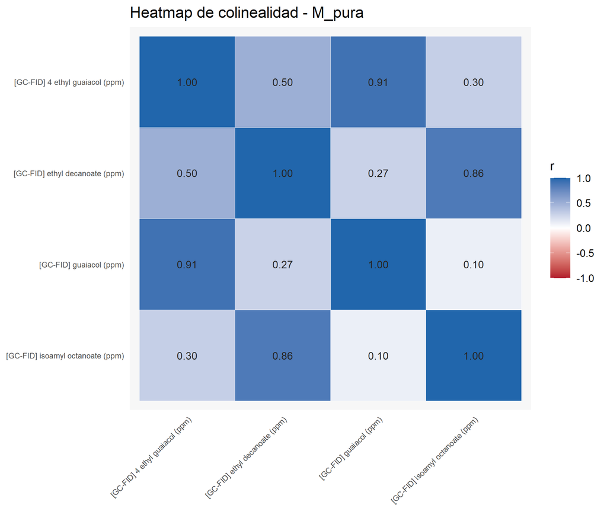

**Escenario `M_cata_individual`**

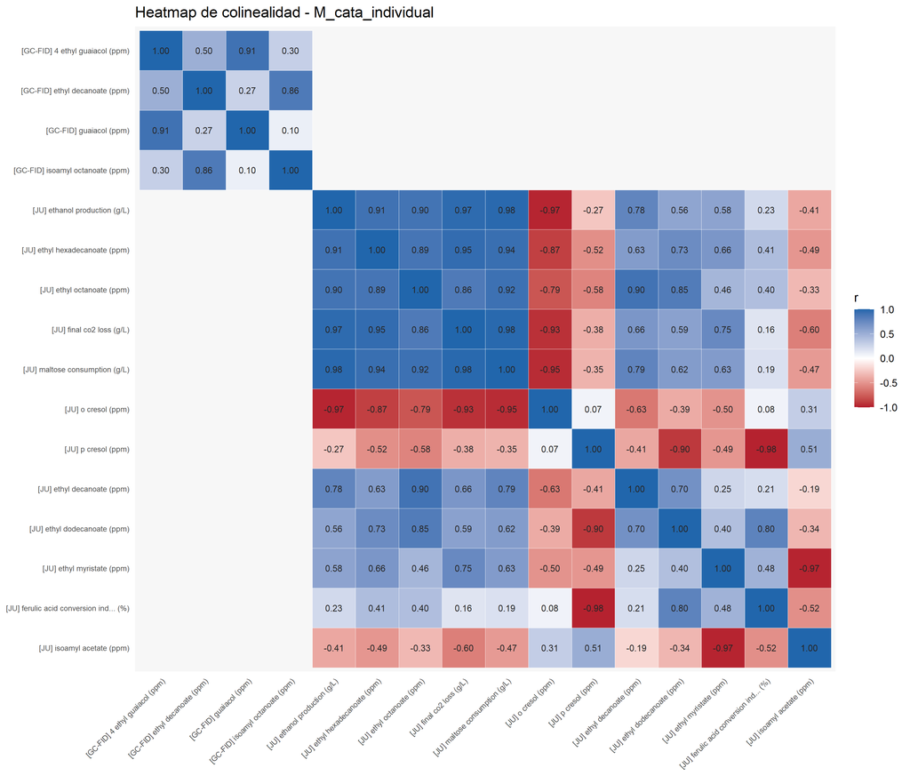

Al agregar la cata individual JU (52 filas), el bloque JU sí alcanza el umbral y aparece con 12 variables — es, por lejos, el bloque más internamente colineal: casi todas las variables fermentativas (producción de etanol, pérdida de CO₂, consumo de maltosa, varios ésteres de cadena larga) se mueven juntas con r > 0.85, coherente con que todas reflejan el mismo proceso de fermentación medido de distintas formas. o-cresol y p-cresol, en cambio, correlacionan negativamente con ese grupo (hasta r = -0.97), y p-cresol en particular con el índice FACI (r = -0.98) — señal de que estos dos compuestos siguen una dinámica distinta al resto de las variables JU. Los bloques GC-FID y GC-MS mantienen el mismo patrón que en `M_pura`, porque siguen siendo las mismas 34 muestras químicas de base.

**Escenario `M_expandida_evaluador`**

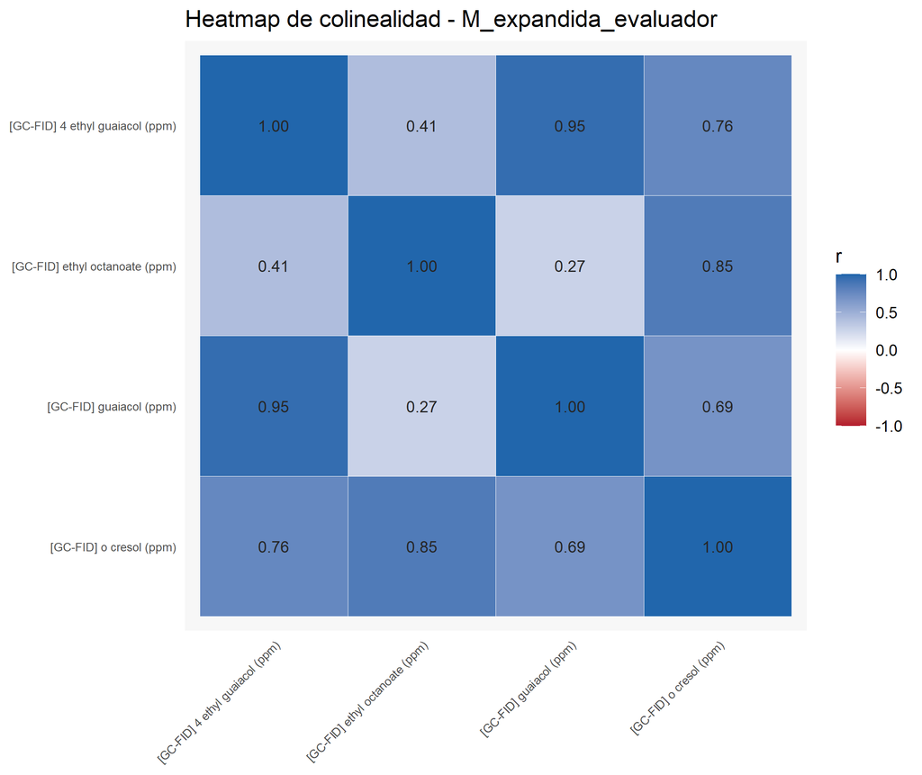

**Escenario `M_ia_exploratoria`**

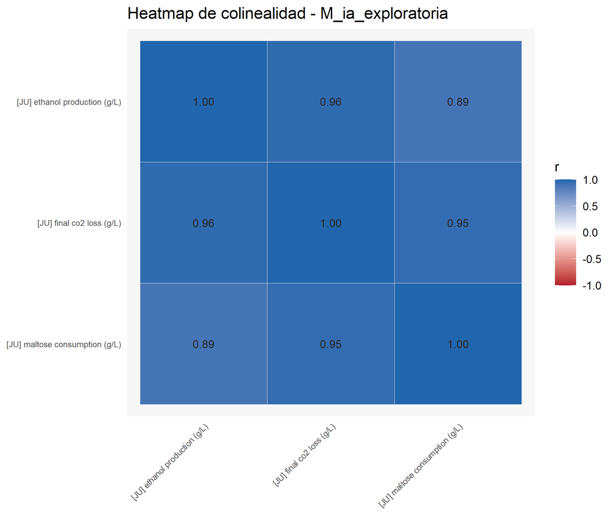

En el escenario sintético de IA, solo el bloque JU alcanza el umbral de colinealidad alta, con tres variables fermentativas correlacionadas entre sí (r = 0.89–0.96). Los bloques GC-FID y GC-MS no aparecen porque este escenario tiene menor cobertura química real detrás de las muestras sintéticas, así que ningún par de esas variables llega al mínimo de pares con datos en común necesario para calcular una correlación confiable.

**Escenario `M_quimica`**

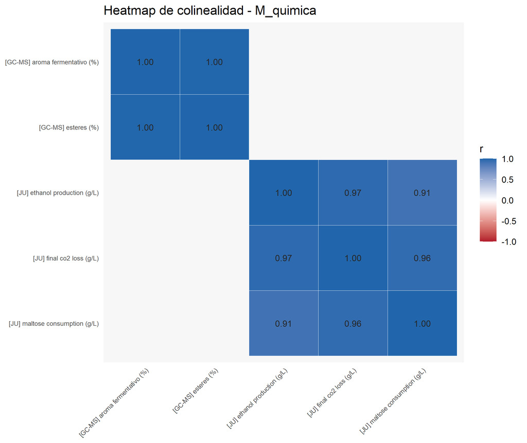

Esta matriz no tiene target sensorial (es solo diagnóstico de la parte química), y su heatmap muestra el caso más extremo de colinealidad interna: aroma fermentativo y ésteres de GC-MS quedan perfectamente correlacionados (r = 1.00, por construcción), y las tres variables fermentativas de JU repiten el mismo patrón visto en `M_ia_exploratoria` (r = 0.91–0.97). El bloque GC-FID no alcanza aquí el umbral porque, al no cruzarse con cata real, cambia qué unidades quedan con datos completos.

En conjunto, los cinco mapas muestran que la colinealidad es una propiedad de la química de base (se repite en `M_pura`, `M_cata_individual` y `M_expandida_evaluador` porque comparten las mismas 34 muestras), y que los bloques con menos cobertura real (`M_ia_exploratoria`, `M_quimica`) simplemente no alcanzan el mínimo de datos para mostrar todos los bloques a la vez.

## 3.6 Modelos base (líneas de comparación)

| escenario | target | modelo | n_observaciones | n_grupos_validacion | mae | rmse | r2 | spearman | bias | mae_media | rmse_media | mejora_mae_vs_media | mejora_rmse_vs_media | lectura |
| --- | --- | --- | --- | --- | --- | --- | --- | --- | --- | --- | --- | --- | --- | --- |
| M_cata_individual | y_fenolico_comun | lineal_reducido | 52 | 16 | 0.578247 | 0.779163 | 0.524293 | 0.516589 | -0.505555 | 0.941580 | 1.129688 | 0.363333 | 0.350525 | mejora_frente_a_media; interpretar_con_cautela_por_small_data_y_colinealidad |
| M_cata_individual | y_fenolico_comun | media_entrenamiento | 52 | 16 | 0.941580 | 1.129688 | 0.000000 | NA | -0.018872 | 0.941580 | 1.129688 | 0.000000 | 0.000000 | linea_base_minima; cualquier_modelo_debe_superar_este_error |
| M_cata_individual | y_frutal_comun | lineal_reducido | 13 | 7 | 0.828500 | 1.126336 | -9.790856 | 0.275298 | 0.566887 | 0.279017 | 0.342878 | -0.549483 | -0.783458 | no_mejora_claramente_frente_a_media_o_mejora_marginal |
| M_cata_individual | y_frutal_comun | media_entrenamiento | 13 | 7 | 0.279017 | 0.342878 | 0.000000 | NA | 0.010812 | 0.279017 | 0.342878 | 0.000000 | 0.000000 | linea_base_minima; cualquier_modelo_debe_superar_este_error |
| M_expandida_evaluador | y_fenolico_comun | lineal_reducido | 685 | 10 | 0.874476 | 1.086593 | -0.027218 | -0.192054 | -0.187008 | 0.862678 | 1.072101 | -0.011798 | -0.014492 | no_mejora_claramente_frente_a_media_o_mejora_marginal |
| M_expandida_evaluador | y_fenolico_comun | media_entrenamiento | 685 | 10 | 0.862678 | 1.072101 | 0.000000 | NA | -0.022174 | 0.862678 | 1.072101 | 0.000000 | 0.000000 | linea_base_minima; cualquier_modelo_debe_superar_este_error |
| M_expandida_evaluador | y_frutal_comun | lineal_reducido | 118 | 7 | 1.319211 | 1.567637 | -3.398731 | 0.182200 | 0.210658 | 0.580064 | 0.747449 | -0.739147 | -0.820188 | no_mejora_claramente_frente_a_media_o_mejora_marginal |
| M_expandida_evaluador | y_frutal_comun | media_entrenamiento | 118 | 7 | 0.580064 | 0.747449 | 0.000000 | NA | 0.012739 | 0.580064 | 0.747449 | 0.000000 | 0.000000 | linea_base_minima; cualquier_modelo_debe_superar_este_error |
| M_ia_exploratoria | y_fenolico_comun | lineal_reducido | 42 | 14 | 0.654554 | 0.816136 | 0.374628 | 0.656910 | -0.341331 | 0.857143 | 1.032031 | 0.202589 | 0.215895 | mejora_frente_a_media; interpretar_con_cautela_por_small_data_y_colinealidad |
| M_ia_exploratoria | y_fenolico_comun | media_entrenamiento | 42 | 14 | 0.857143 | 1.032031 | 0.000000 | NA | 0.000000 | 0.857143 | 1.032031 | 0.000000 | 0.000000 | linea_base_minima; cualquier_modelo_debe_superar_este_error |
| M_pura | y_fenolico_comun | lineal_reducido | 34 | 10 | 0.473443 | 0.606387 | -0.121447 | -0.424062 | -0.023350 | 0.459241 | 0.572612 | -0.014202 | -0.033775 | no_mejora_claramente_frente_a_media_o_mejora_marginal |
| M_pura | y_fenolico_comun | media_entrenamiento | 34 | 10 | 0.459241 | 0.572612 | 0.000000 | NA | 0.000716 | 0.459241 | 0.572612 | 0.000000 | 0.000000 | linea_base_minima; cualquier_modelo_debe_superar_este_error |
| M_pura | y_frutal_comun | lineal_reducido | 13 | 7 | 0.828500 | 1.126336 | -9.790856 | 0.275298 | 0.566887 | 0.279017 | 0.342878 | -0.549483 | -0.783458 | no_mejora_claramente_frente_a_media_o_mejora_marginal |
| M_pura | y_frutal_comun | media_entrenamiento | 13 | 7 | 0.279017 | 0.342878 | 0.000000 | NA | 0.010812 | 0.279017 | 0.342878 | 0.000000 | 0.000000 | linea_base_minima; cualquier_modelo_debe_superar_este_error |

** 01_modelo_base_mae_por_escenario **

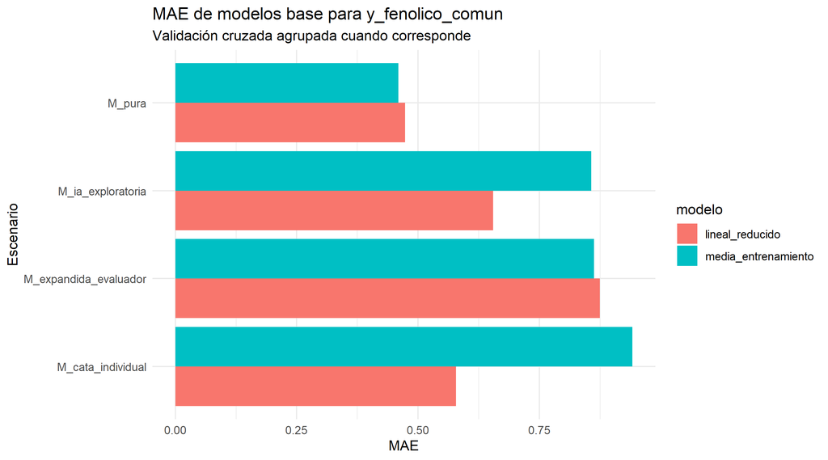

## 3.7 Modelos candidatos (small data)

| escenario | target | modelo | n_observaciones | n_grupos_validacion | mae | rmse | r2 | spearman | bias | mae_lineal_reducido | mae_media_entrenamiento | rmse_lineal_reducido | rmse_media_entrenamiento | mejora_mae_vs_media | mejora_mae_vs_lineal | lectura_comparativa |
| --- | --- | --- | --- | --- | --- | --- | --- | --- | --- | --- | --- | --- | --- | --- | --- | --- |
| M_cata_individual | y_fenolico_comun | random_forest_restringido | 52 | 16 | 0.395186 | 0.557655 | 0.716741 | 0.639102 | -0.058902 | 0.578247 | 0.941580 | 0.779163 | 1.129688 | 0.546394 | 0.183061 | mejora_frente_a_lineal_reducido |
| M_cata_individual | y_fenolico_comun | lasso | 52 | 16 | 0.723931 | 0.926187 | 0.218644 | 0.431302 | -0.503649 | 0.578247 | 0.941580 | 0.779163 | 1.129688 | 0.217649 | -0.145684 | mejora_solo_frente_a_media |
| M_cata_individual | y_fenolico_comun | ridge | 52 | 16 | 0.746584 | 0.927910 | 0.215734 | 0.527907 | -0.534070 | 0.578247 | 0.941580 | 0.779163 | 1.129688 | 0.194996 | -0.168337 | mejora_solo_frente_a_media |
| M_cata_individual | y_fenolico_comun | elastic_net | 52 | 16 | 0.827379 | 0.995912 | 0.096571 | 0.668255 | -0.496827 | 0.578247 | 0.941580 | 0.779163 | 1.129688 | 0.114201 | -0.249132 | mejora_solo_frente_a_media |
| M_cata_individual | y_fenolico_comun | pls | 52 | 16 | 0.830616 | 0.996688 | 0.095163 | 0.695660 | -0.676197 | 0.578247 | 0.941580 | 0.779163 | 1.129688 | 0.110964 | -0.252369 | mejora_solo_frente_a_media |
| M_cata_individual | y_fenolico_comun | gradient_boosting_restringido | 52 | 16 | 0.887898 | 1.071023 | -0.044840 | -0.232264 | -0.060658 | 0.578247 | 0.941580 | 0.779163 | 1.129688 | 0.053682 | -0.309651 | mejora_solo_frente_a_media |
| M_cata_individual | y_frutal_comun | random_forest_restringido | 13 | 7 | 0.293607 | 0.348867 | -0.553875 | -0.564325 | 0.120365 | 0.828500 | 0.279017 | 1.126336 | 0.342878 | -0.014590 | 0.534893 | mejora_frente_a_lineal_reducido |
| M_cata_individual | y_frutal_comun | gradient_boosting_restringido | 13 | 7 | 0.300492 | 0.360536 | -0.659559 | -0.880682 | 0.133787 | 0.828500 | 0.279017 | 1.126336 | 0.342878 | -0.021475 | 0.528008 | mejora_frente_a_lineal_reducido |
| M_cata_individual | y_frutal_comun | elastic_net | 13 | 7 | 0.345589 | 0.398587 | -1.028350 | -0.860456 | 0.127285 | 0.828500 | 0.279017 | 1.126336 | 0.342878 | -0.066572 | 0.482911 | mejora_frente_a_lineal_reducido |
| M_cata_individual | y_frutal_comun | lasso | 13 | 7 | 0.380002 | 0.417181 | -1.222001 | -0.631374 | 0.157113 | 0.828500 | 0.279017 | 1.126336 | 0.342878 | -0.100985 | 0.448498 | mejora_frente_a_lineal_reducido |
| M_cata_individual | y_frutal_comun | ridge | 13 | 7 | 0.401180 | 0.448990 | -1.573762 | -0.720772 | 0.206059 | 0.828500 | 0.279017 | 1.126336 | 0.342878 | -0.122163 | 0.427320 | mejora_frente_a_lineal_reducido |
| M_cata_individual | y_frutal_comun | pls | 13 | 7 | 0.476117 | 0.592588 | -3.483336 | -0.659310 | 0.372425 | 0.828500 | 0.279017 | 1.126336 | 0.342878 | -0.197100 | 0.352383 | mejora_frente_a_lineal_reducido |
| M_expandida_evaluador | y_fenolico_comun | random_forest_restringido | 685 | 10 | 0.809772 | 0.994088 | -0.007874 | 0.216853 | 0.013374 | 0.874476 | 0.862678 | 1.086593 | 1.072101 | 0.052906 | 0.064704 | mejora_frente_a_lineal_reducido |
| M_expandida_evaluador | y_fenolico_comun | gradient_boosting_restringido | 685 | 10 | 0.821165 | 1.009036 | -0.038412 | 0.112963 | 0.031331 | 0.874476 | 0.862678 | 1.086593 | 1.072101 | 0.041513 | 0.053311 | mejora_frente_a_lineal_reducido |
| M_expandida_evaluador | y_fenolico_comun | ridge | 685 | 10 | 0.823224 | 1.019507 | -0.060076 | 0.375580 | -0.020365 | 0.874476 | 0.862678 | 1.086593 | 1.072101 | 0.039454 | 0.051252 | mejora_frente_a_lineal_reducido |
| M_expandida_evaluador | y_fenolico_comun | pls | 685 | 10 | 0.884007 | 1.076911 | -0.182813 | 0.339170 | -0.112785 | 0.874476 | 0.862678 | 1.086593 | 1.072101 | -0.021329 | -0.009531 | no_mejora_frente_a_base |
| M_expandida_evaluador | y_fenolico_comun | elastic_net | 685 | 10 | 0.913378 | 1.090596 | -0.213065 | -0.074786 | 0.250353 | 0.874476 | 0.862678 | 1.086593 | 1.072101 | -0.050700 | -0.038902 | no_mejora_frente_a_base |
| M_expandida_evaluador | y_fenolico_comun | lasso | 685 | 10 | 0.944377 | 1.121849 | -0.283588 | -0.101144 | 0.357993 | 0.874476 | 0.862678 | 1.086593 | 1.072101 | -0.081699 | -0.069901 | no_mejora_frente_a_base |
| M_expandida_evaluador | y_frutal_comun | random_forest_restringido | 118 | 7 | 0.555753 | 0.749906 | -0.080784 | -0.242891 | 0.109354 | 1.319211 | 0.580064 | 1.567637 | 0.747449 | 0.024311 | 0.763458 | mejora_frente_a_lineal_reducido |
| M_expandida_evaluador | y_frutal_comun | gradient_boosting_restringido | 118 | 7 | 0.566677 | 0.751563 | -0.085566 | -0.249940 | 0.082715 | 1.319211 | 0.580064 | 1.567637 | 0.747449 | 0.013387 | 0.752534 | mejora_frente_a_lineal_reducido |
| M_expandida_evaluador | y_frutal_comun | pls | 118 | 7 | 0.570247 | 0.763175 | -0.119371 | -0.188403 | 0.129033 | 1.319211 | 0.580064 | 1.567637 | 0.747449 | 0.009817 | 0.748964 | mejora_frente_a_lineal_reducido |
| M_expandida_evaluador | y_frutal_comun | ridge | 118 | 7 | 0.575375 | 0.765949 | -0.127523 | -0.162776 | 0.160130 | 1.319211 | 0.580064 | 1.567637 | 0.747449 | 0.004689 | 0.743836 | mejora_frente_a_lineal_reducido |
| M_expandida_evaluador | y_frutal_comun | elastic_net | 118 | 7 | 0.580297 | 0.771194 | -0.143018 | -0.225949 | 0.173748 | 1.319211 | 0.580064 | 1.567637 | 0.747449 | -0.000233 | 0.738914 | mejora_frente_a_lineal_reducido |
| M_expandida_evaluador | y_frutal_comun | lasso | 118 | 7 | 0.632394 | 0.808076 | -0.254960 | -0.285275 | -0.088143 | 1.319211 | 0.580064 | 1.567637 | 0.747449 | -0.052330 | 0.686817 | mejora_frente_a_lineal_reducido |
| M_ia_exploratoria | y_fenolico_comun | random_forest_restringido | 42 | 14 | 0.598574 | 0.705749 | 0.457644 | 0.614813 | -0.054061 | 0.654554 | 0.857143 | 0.816136 | 1.032031 | 0.258569 | 0.055980 | mejora_frente_a_lineal_reducido |
| M_ia_exploratoria | y_fenolico_comun | gradient_boosting_restringido | 42 | 14 | 0.662257 | 0.763049 | 0.366002 | 0.524927 | -0.019477 | 0.654554 | 0.857143 | 0.816136 | 1.032031 | 0.194886 | -0.007703 | mejora_solo_frente_a_media |
| M_ia_exploratoria | y_fenolico_comun | ridge | 42 | 14 | 0.709065 | 0.791521 | 0.317806 | 0.666633 | -0.270221 | 0.654554 | 0.857143 | 0.816136 | 1.032031 | 0.148078 | -0.054511 | mejora_solo_frente_a_media |
| M_ia_exploratoria | y_fenolico_comun | pls | 42 | 14 | 0.786904 | 0.908152 | 0.101950 | 0.619200 | -0.173945 | 0.654554 | 0.857143 | 0.816136 | 1.032031 | 0.070239 | -0.132350 | mejora_solo_frente_a_media |
| M_ia_exploratoria | y_fenolico_comun | elastic_net | 42 | 14 | 0.839531 | 0.994669 | -0.077311 | 0.590388 | -0.072084 | 0.654554 | 0.857143 | 0.816136 | 1.032031 | 0.017612 | -0.184977 | mejora_solo_frente_a_media |
| M_ia_exploratoria | y_fenolico_comun | lasso | 42 | 14 | 0.897475 | 1.145776 | -0.429497 | 0.580578 | 0.003907 | 0.654554 | 0.857143 | 0.816136 | 1.032031 | -0.040332 | -0.242921 | no_mejora_frente_a_base |
| M_pura | y_fenolico_comun | ridge | 34 | 10 | 0.404981 | 0.478896 | 0.059011 | 0.300448 | 0.033456 | 0.473443 | 0.459241 | 0.606387 | 0.572612 | 0.054260 | 0.068462 | mejora_frente_a_lineal_reducido |
| M_pura | y_fenolico_comun | random_forest_restringido | 34 | 10 | 0.422358 | 0.516515 | -0.094631 | 0.041648 | 0.075002 | 0.473443 | 0.459241 | 0.606387 | 0.572612 | 0.036883 | 0.051085 | mejora_frente_a_lineal_reducido |
| M_pura | y_fenolico_comun | elastic_net | 34 | 10 | 0.442036 | 0.563847 | -0.304438 | -0.045029 | 0.130220 | 0.473443 | 0.459241 | 0.606387 | 0.572612 | 0.017205 | 0.031407 | mejora_frente_a_lineal_reducido |
| M_pura | y_fenolico_comun | pls | 34 | 10 | 0.467815 | 0.541674 | -0.203862 | 0.059168 | 0.050507 | 0.473443 | 0.459241 | 0.606387 | 0.572612 | -0.008574 | 0.005628 | mejora_frente_a_lineal_reducido |
| M_pura | y_fenolico_comun | gradient_boosting_restringido | 34 | 10 | 0.489332 | 0.586236 | -0.410088 | -0.215178 | 0.159907 | 0.473443 | 0.459241 | 0.606387 | 0.572612 | -0.030091 | -0.015889 | no_mejora_frente_a_base |
| M_pura | y_fenolico_comun | lasso | 34 | 10 | 0.545034 | 0.627120 | -0.613626 | -0.047641 | 0.284645 | 0.473443 | 0.459241 | 0.606387 | 0.572612 | -0.085793 | -0.071591 | no_mejora_frente_a_base |
| M_pura | y_frutal_comun | random_forest_restringido | 13 | 7 | 0.293607 | 0.348867 | -0.553875 | -0.564325 | 0.120365 | 0.828500 | 0.279017 | 1.126336 | 0.342878 | -0.014590 | 0.534893 | mejora_frente_a_lineal_reducido |
| M_pura | y_frutal_comun | gradient_boosting_restringido | 13 | 7 | 0.301532 | 0.363094 | -0.683194 | -0.676136 | 0.138686 | 0.828500 | 0.279017 | 1.126336 | 0.342878 | -0.022515 | 0.526968 | mejora_frente_a_lineal_reducido |
| M_pura | y_frutal_comun | lasso | 13 | 7 | 0.373913 | 0.427132 | -1.329274 | -0.737534 | 0.213846 | 0.828500 | 0.279017 | 1.126336 | 0.342878 | -0.094896 | 0.454587 | mejora_frente_a_lineal_reducido |
| M_pura | y_frutal_comun | elastic_net | 13 | 7 | 0.390182 | 0.444257 | -1.519786 | -0.698422 | 0.177308 | 0.828500 | 0.279017 | 1.126336 | 0.342878 | -0.111165 | 0.438318 | mejora_frente_a_lineal_reducido |
| M_pura | y_frutal_comun | ridge | 13 | 7 | 0.393211 | 0.438659 | -1.456691 | -0.586675 | 0.196040 | 0.828500 | 0.279017 | 1.126336 | 0.342878 | -0.114194 | 0.435289 | mejora_frente_a_lineal_reducido |
| M_pura | y_frutal_comun | pls | 13 | 7 | 0.476117 | 0.592588 | -3.483336 | -0.659310 | 0.372425 | 0.828500 | 0.279017 | 1.126336 | 0.342878 | -0.197100 | 0.352383 | mejora_frente_a_lineal_reducido |

Esta tabla compara los 6 modelos candidatos con una sola pasada de validación cruzada por escenario/target — útil para ver el orden de magnitud y detectar modelos que ni siquiera superan la media de entrenamiento (columna `lectura_comparativa`), pero todavía sensible a cómo caen las particiones. La comparación que realmente define el modelo recomendado es la del bootstrap agrupado (100 iteraciones), en la siguiente sección.

** 01_modelos_small_data_mae_y_fenolico **

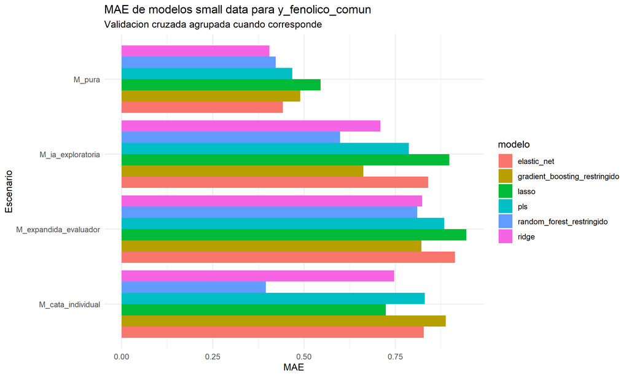

** 02_importancia_variables_y_fenolico_M_pura **

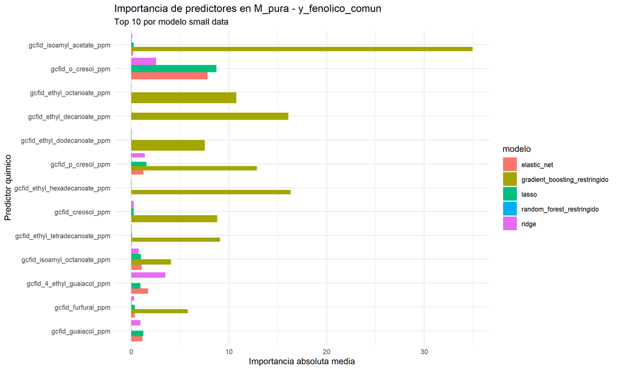

## 3.8 Validación por bootstrap agrupado

Validación con 100 iteraciones de bootstrap, agrupando por unidad analítica para evitar fuga de información entre entrenamiento y prueba cuando una misma muestra química aparece en más de una fila (por ejemplo, distintos evaluadores en `M_expandida_evaluador`). En cada iteración se remuestrea con reemplazo a nivel de unidad química completa, se ajustan los 6 modelos candidatos y se promedian sus métricas — así el resultado deja de depender de una sola partición afortunada o desafortunada.

**Manejo de datos faltantes**: cada predictor con valores faltantes se imputa por su mediana, calculada únicamente con las filas del pliegue de entrenamiento de esa iteración de bootstrap, y esa misma mediana (no una nueva, calculada con datos de prueba) se aplica tanto al pliegue de entrenamiento como al de prueba. Esto evita fuga de información: en ningún caso la imputación de una fila de prueba usa información de esa misma fila u otras filas de prueba. La misma lógica se aplica de forma idéntica en los modelos base y en los modelos candidatos.

| escenario | target | modelo | n_bootstrap_exitosos | n_fallback_holdout | pct_fallback_holdout | n_train_promedio | n_test_promedio | mae_media | mae_sd | mae_p05 | mae_p50 | mae_p95 | rmse_media | rmse_sd | rmse_p05 | rmse_p50 | rmse_p95 | r2_media | r2_p05 | r2_p50 | r2_p95 | r2_pct_positivo | r2_agregado | spearman_media | spearman_p50 | bias_media | mae_ic90_ancho | estabilidad_error | es_candidato | … |
| --- | --- | --- | --- | --- | --- | --- | --- | --- | --- | --- | --- | --- | --- | --- | --- | --- | --- | --- | --- | --- | --- | --- | --- | --- | --- | --- | --- | --- | --- | --- |
| M_cata_individual | y_fenolico_comun | random_forest_restringido | 100 | 0 | 0.0 | 51.95000 | 19.610000 | 0.5149154 | 0.2145000 | 0.2392262 | 0.4801817 | 0.8911657 | 0.6472388 | 0.2488011 | 0.3083318 | 0.6456386 | 1.0342715 | 0.6601336 | 0.2671084 | 0.6949212 | 0.9296722 | 100.0 | 0.6472861 | 0.6893026 | 0.7520449 | -0.0263972 | 0.6519396 | baja | TRUE | … |
| M_cata_individual | y_fenolico_comun | gradient_boosting_restringido | 100 | 0 | 0.0 | 51.95000 | 19.610000 | 0.7070758 | 0.3100421 | 0.2946954 | 0.6868770 | 1.2085831 | 0.8532403 | 0.3300262 | 0.3499459 | 0.8464956 | 1.4353231 | 0.4489266 | 0.0120670 | 0.4000062 | 0.7949702 | 96.0 | 0.4254635 | 0.6580063 | 0.6811407 | 0.1059248 | 0.9138877 | baja | TRUE | … |
| M_cata_individual | y_fenolico_comun | ridge | 100 | 0 | 0.0 | 51.95000 | 19.610000 | 0.9968061 | 0.4963083 | 0.3555527 | 0.9191197 | 1.9634177 | 1.1850227 | 0.5329140 | 0.5087013 | 1.0624728 | 2.1893736 | -0.4340194 | -3.1712015 | 0.0381945 | 0.8483454 | 52.0 | -0.2483111 | 0.4039297 | 0.5272840 | -0.0886890 | 1.6078651 | baja | TRUE | … |
| M_cata_individual | y_fenolico_comun | elastic_net | 100 | 0 | 0.0 | 51.95000 | 19.610000 | 1.0237438 | 0.5242480 | 0.3298180 | 0.9713321 | 1.9706199 | 1.2552657 | 0.6060718 | 0.4684218 | 1.1823566 | 2.2094407 | -0.6582709 | -4.6366495 | 0.0255833 | 0.8419512 | 51.0 | -0.4198440 | 0.3917375 | 0.5440799 | -0.0222283 | 1.6408019 | baja | TRUE | … |
| M_cata_individual | y_fenolico_comun | lasso | 100 | 0 | 0.0 | 51.95000 | 19.610000 | 1.0294325 | 0.5613674 | 0.2522458 | 0.9597664 | 2.0809203 | 1.2574766 | 0.6352410 | 0.4465897 | 1.2027214 | 2.3336253 | -0.6045539 | -3.9691768 | 0.0000000 | 0.9070944 | 48.0 | -0.4731022 | 0.3564892 | 0.4589302 | 0.0186394 | 1.8286745 | baja | TRUE | … |
| M_cata_individual | y_fenolico_comun | pls | 100 | 0 | 0.0 | 51.95000 | 19.610000 | 1.0959598 | 0.5490396 | 0.3778755 | 0.9895368 | 2.1006302 | 1.3109211 | 0.5979330 | 0.5105500 | 1.1852703 | 2.3431212 | -0.9546260 | -6.5499842 | -0.0421608 | 0.8074040 | 48.0 | -0.5432844 | 0.4033488 | 0.4871500 | -0.0623859 | 1.7227546 | baja | TRUE | … |
| M_cata_individual | y_fenolico_comun | media_entrenamiento | 100 | 0 | 0.0 | 51.95000 | 19.610000 | 1.0104973 | 0.2923721 | 0.5559143 | 1.0278889 | 1.4428402 | 1.1682536 | 0.2926164 | 0.6869215 | 1.2179192 | 1.5873924 | 0.0000000 | 0.0000000 | 0.0000000 | 0.0000000 | 0.0 | 0.0000000 | NA | NA | -0.0135040 | 0.8869259 | baja | FALSE | … |
| M_cata_individual | y_fenolico_comun | lineal_reducido | 100 | 0 | 0.0 | 51.95000 | 19.610000 | 1.0170500 | 0.4002036 | 0.4878724 | 0.9745731 | 1.9073121 | 1.2736717 | 0.4783418 | 0.6975619 | 1.2197514 | 2.2809287 | -0.5290494 | -3.0285994 | -0.0099531 | 0.7404416 | 50.0 | -0.3395527 | 0.2060528 | 0.1780003 | -0.0351959 | 1.4194397 | baja | FALSE | … |
| M_cata_individual | y_frutal_comun | random_forest_restringido | 88 | 15 | 17.0 | 13.13636 | 4.318182 | 0.3294268 | 0.1401560 | 0.1236311 | 0.3500000 | 0.5597211 | 0.3594929 | 0.1345737 | 0.1313768 | 0.3539832 | 0.5609100 | -0.7616312 | -4.8556325 | -0.0270775 | 0.5514832 | 43.2 | -0.0226659 | 0.0142722 | 0.0000000 | 0.0714340 | 0.4360900 | media | TRUE | … |
| M_cata_individual | y_frutal_comun | gradient_boosting_restringido | 88 | 15 | 17.0 | 13.13636 | 4.318182 | 0.3645769 | 0.1501515 | 0.1376330 | 0.3500000 | 0.6166369 | 0.3908723 | 0.1511166 | 0.1503003 | 0.3895527 | 0.6175729 | -1.0216354 | -4.9744575 | -0.2045218 | 0.6776146 | 30.7 | -0.2399150 | -0.3120212 | -0.9332565 | 0.0760428 | 0.4790038 | media | TRUE | … |
| M_cata_individual | y_frutal_comun | ridge | 87 | 15 | 17.2 | 13.16092 | 4.287356 | 0.4594844 | 0.2357255 | 0.1970660 | 0.4278679 | 0.7462432 | 0.4958018 | 0.2514955 | 0.2227270 | 0.4721605 | 0.7868674 | -10.2734873 | -31.8216709 | -0.2119087 | 0.4138277 | 32.2 | -1.5745286 | -0.4273189 | -0.7745967 | 0.1776281 | 0.5491773 | baja | TRUE | … |
| M_cata_individual | y_frutal_comun | lasso | 87 | 15 | 17.2 | 13.16092 | 4.287356 | 0.4725554 | 0.2994721 | 0.1796386 | 0.3978870 | 1.0751835 | 0.5150005 | 0.3311324 | 0.2086571 | 0.4463412 | 1.2864973 | -7.9204645 | -44.5253029 | -0.1252348 | 0.3244615 | 28.7 | -2.1608672 | -0.2508371 | -0.4862617 | 0.1929864 | 0.8955449 | baja | TRUE | … |
| M_cata_individual | y_frutal_comun | elastic_net | 88 | 15 | 17.0 | 13.13636 | 4.318182 | 0.5226696 | 0.3897770 | 0.1801896 | 0.4396817 | 1.3915184 | 0.5681947 | 0.4328012 | 0.2092592 | 0.4673104 | 1.7070353 | -5.2227880 | -26.6370616 | -0.3701097 | 0.3574719 | 26.1 | -3.8662100 | -0.3713616 | -0.7745967 | 0.1870695 | 1.2113288 | baja | TRUE | … |
| M_cata_individual | y_frutal_comun | pls | 88 | 15 | 17.0 | 13.13636 | 4.318182 | 0.5798580 | 0.3624546 | 0.1633231 | 0.5253624 | 1.2555466 | 0.6380506 | 0.4045701 | 0.2001817 | 0.5719645 | 1.6031125 | -28.6564985 | -53.5809381 | -0.4390044 | 0.5910180 | 28.4 | -4.0210041 | -0.3777005 | -0.7745967 | 0.3016812 | 1.0922236 | baja | TRUE | … |
| M_cata_individual | y_frutal_comun | media_entrenamiento | 88 | 15 | 17.0 | 13.13636 | 4.318182 | 0.3208913 | 0.1413344 | 0.0601852 | 0.3464394 | 0.5228333 | 0.3527249 | 0.1374221 | 0.1148596 | 0.3800750 | 0.5320335 | 0.0000000 | 0.0000000 | 0.0000000 | 0.0000000 | 0.0 | 0.0000000 | NA | NA | -0.0034744 | 0.4626481 | media | FALSE | … |
| M_cata_individual | y_frutal_comun | lineal_reducido | 88 | 15 | 17.0 | 13.13636 | 4.318182 | 0.8996410 | 0.6236212 | 0.2357331 | 0.7263389 | 2.0364721 | 1.0004029 | 0.6913521 | 0.2607351 | 0.7753852 | 2.2280934 | -130.6671037 | -266.7834872 | -3.7078682 | 0.4424255 | 20.5 | -10.5271334 | -0.0211390 | 0.0000000 | 0.2093902 | 1.8007390 | baja | FALSE | … |
| M_expandida_evaluador | y_fenolico_comun | random_forest_restringido | 100 | 2 | 2.0 | 689.94000 | 222.480000 | 0.8225619 | 0.1556768 | 0.6269890 | 0.7630143 | 1.1251350 | 0.9957123 | 0.1863082 | 0.7661003 | 0.9237947 | 1.3360050 | 0.0841285 | -0.2327202 | 0.0790594 | 0.3778455 | 69.0 | 0.1087074 | 0.0978423 | 0.0610149 | 0.0050365 | 0.4981460 | media | TRUE | … |
| M_expandida_evaluador | y_fenolico_comun | gradient_boosting_restringido | 100 | 2 | 2.0 | 689.94000 | 222.480000 | 0.8349415 | 0.1608809 | 0.6286252 | 0.7937256 | 1.1363428 | 1.0106248 | 0.1908639 | 0.7635822 | 0.9585589 | 1.3379293 | 0.0520728 | -0.3642860 | 0.0693178 | 0.3986668 | 64.0 | 0.0893395 | 0.1147972 | 0.0626815 | 0.0236561 | 0.5077175 | baja | TRUE | … |
| M_expandida_evaluador | y_fenolico_comun | ridge | 100 | 2 | 2.0 | 689.94000 | 222.480000 | 0.9201312 | 0.2290135 | 0.6250158 | 0.8774786 | 1.3603676 | 1.1190199 | 0.2657399 | 0.7947031 | 1.0670495 | 1.6274350 | -0.2662086 | -1.6181258 | -0.0438921 | 0.3864097 | 44.0 | -0.2133889 | 0.0877453 | 0.0610149 | -0.0280789 | 0.7353518 | baja | TRUE | … |
| M_expandida_evaluador | y_fenolico_comun | pls | 100 | 2 | 2.0 | 689.94000 | 222.480000 | 0.9924390 | 0.2713069 | 0.6659729 | 0.9754350 | 1.4724145 | 1.1998145 | 0.2974783 | 0.8518651 | 1.1552005 | 1.6986323 | -0.5299843 | -2.9546297 | -0.1685499 | 0.3709399 | 37.0 | -0.3652895 | 0.0740353 | 0.0562589 | -0.0038011 | 0.8064416 | baja | TRUE | … |
| M_expandida_evaluador | y_fenolico_comun | elastic_net | 100 | 2 | 2.0 | 689.94000 | 222.480000 | 1.0263436 | 0.3533269 | 0.6348139 | 0.9331884 | 1.8664600 | 1.2265162 | 0.3778966 | 0.7885017 | 1.1221339 | 2.1187733 | -0.6820857 | -5.3116840 | -0.0574345 | 0.3274483 | 42.0 | -0.4939465 | 0.0867242 | 0.0610149 | -0.0050981 | 1.2316461 | baja | TRUE | … |
| M_expandida_evaluador | y_fenolico_comun | lasso | 100 | 2 | 2.0 | 689.94000 | 222.480000 | 1.0366704 | 0.3407810 | 0.6636978 | 0.9491488 | 1.8666169 | 1.2398741 | 0.3607614 | 0.8042324 | 1.1449811 | 2.1074943 | -0.7081829 | -5.4191400 | -0.0970538 | 0.3429281 | 40.0 | -0.4913250 | 0.0936670 | 0.0618482 | 0.0124536 | 1.2029190 | baja | TRUE | … |
| M_expandida_evaluador | y_fenolico_comun | media_entrenamiento | 100 | 2 | 2.0 | 689.94000 | 222.480000 | 0.8652672 | 0.1763268 | 0.6591088 | 0.8248808 | 1.2285907 | 1.0527287 | 0.2083961 | 0.8264278 | 0.9908996 | 1.4568705 | 0.0000000 | 0.0000000 | 0.0000000 | 0.0000000 | 0.0 | 0.0000000 | NA | NA | -0.0299108 | 0.5694818 | baja | FALSE | … |
| M_expandida_evaluador | y_fenolico_comun | lineal_reducido | 100 | 2 | 2.0 | 689.94000 | 222.480000 | 1.0119929 | 0.3940513 | 0.6446313 | 0.9154080 | 1.9128853 | 1.2234443 | 0.4233125 | 0.7880597 | 1.1460912 | 2.0885696 | -0.5417700 | -3.3855664 | -0.0720259 | 0.2653052 | 44.0 | -0.5423747 | -0.0156005 | -0.0031792 | -0.0594968 | 1.2682541 | baja | FALSE | … |
| M_expandida_evaluador | y_frutal_comun | gradient_boosting_restringido | 100 | 11 | 11.0 | 113.53000 | 42.810000 | 0.5856735 | 0.1045617 | 0.4392297 | 0.5615597 | 0.7888525 | 0.7731254 | 0.1113274 | 0.6097645 | 0.7659209 | 0.9690419 | -0.0516536 | -0.2345351 | -0.0046611 | 0.0853163 | 44.0 | -0.0490345 | -0.1116826 | -0.0821213 | 0.0781139 | 0.3496228 | media | TRUE | … |
| M_expandida_evaluador | y_frutal_comun | random_forest_restringido | 100 | 11 | 11.0 | 113.53000 | 42.810000 | 0.5886852 | 0.0959316 | 0.4745469 | 0.5771335 | 0.7855922 | 0.7713311 | 0.1055651 | 0.6274920 | 0.7641720 | 0.9649314 | -0.0476065 | -0.2982795 | -0.0151236 | 0.0948250 | 42.0 | -0.0423787 | -0.0220556 | -0.0182242 | 0.0732739 | 0.3110454 | media | TRUE | … |
| M_expandida_evaluador | y_frutal_comun | lasso | 100 | 11 | 11.0 | 113.53000 | 42.810000 | 0.7591041 | 0.3670988 | 0.4986111 | 0.6227329 | 1.8356505 | 0.9452229 | 0.3592710 | 0.6821981 | 0.8286243 | 1.9965165 | -0.9697098 | -7.6203190 | 0.0000000 | 0.0349303 | 23.0 | -1.0278927 | -0.0641330 | -0.0594427 | 0.2395743 | 1.3370394 | baja | TRUE | … |
| M_expandida_evaluador | y_frutal_comun | ridge | 100 | 11 | 11.0 | 113.53000 | 42.810000 | 0.7644040 | 0.3685146 | 0.4972453 | 0.6324937 | 1.7532393 | 0.9533390 | 0.3637447 | 0.6802585 | 0.8339777 | 1.9457426 | -1.0943614 | -7.6186479 | -0.0201882 | 0.0501998 | 26.0 | -1.0373816 | -0.1440042 | -0.1294352 | 0.1712852 | 1.2559940 | baja | TRUE | … |
| M_expandida_evaluador | y_frutal_comun | elastic_net | 100 | 11 | 11.0 | 113.53000 | 42.810000 | 0.8072976 | 0.4522283 | 0.4986111 | 0.6193185 | 1.8718791 | 1.0000596 | 0.4594907 | 0.6835596 | 0.8296539 | 2.0931737 | -1.5461179 | -8.7660238 | -0.0127534 | 0.0316314 | 21.0 | -1.3325751 | -0.0716254 | -0.0435584 | 0.1827151 | 1.3732680 | baja | TRUE | … |
| M_expandida_evaluador | y_frutal_comun | pls | 100 | 11 | 11.0 | 113.53000 | 42.810000 | 0.9139738 | 0.4951332 | 0.5112814 | 0.7006461 | 2.0939573 | 1.1115632 | 0.5101132 | 0.6924262 | 0.9137292 | 2.2563621 | -2.1599518 | -11.8617226 | -0.1835061 | 0.0736066 | 22.0 | -1.9085750 | -0.1327735 | -0.1021702 | 0.0986254 | 1.5826759 | baja | TRUE | … |
| M_expandida_evaluador | y_frutal_comun | media_entrenamiento | 100 | 11 | 11.0 | 113.53000 | 42.810000 | 0.5910437 | 0.0990222 | 0.4457014 | 0.5793655 | 0.8306579 | 0.7579417 | 0.1145092 | 0.5706607 | 0.7573785 | 0.9762530 | 0.0000000 | 0.0000000 | 0.0000000 | 0.0000000 | 0.0 | 0.0000000 | NA | NA | 0.0052742 | 0.3849565 | media | FALSE | … |
| M_expandida_evaluador | y_frutal_comun | lineal_reducido | 100 | 11 | 11.0 | 113.53000 | 42.810000 | 1.1840986 | 0.5173815 | 0.5275906 | 1.0914874 | 1.9402043 | 1.3803872 | 0.5347991 | 0.7217322 | 1.2973524 | 2.1682770 | -3.4245389 | -12.1327492 | -2.1421019 | 0.1852510 | 18.0 | -3.2565222 | 0.0221337 | 0.0202099 | 0.3125582 | 1.4126138 | baja | FALSE | … |
| M_ia_exploratoria | y_fenolico_comun | gradient_boosting_restringido | 100 | 0 | 0.0 | 42.00000 | 15.450000 | 0.6015588 | 0.1612761 | 0.3701306 | 0.5994332 | 0.9039945 | 0.7026570 | 0.1690237 | 0.4302451 | 0.6956138 | 1.0108286 | 0.4105382 | -0.1092824 | 0.5351156 | 0.7902498 | 90.0 | 0.5102545 | 0.7082146 | 0.7723555 | -0.0042027 | 0.5338639 | baja | TRUE | … |
| M_ia_exploratoria | y_fenolico_comun | random_forest_restringido | 100 | 0 | 0.0 | 42.00000 | 15.450000 | 0.6179233 | 0.1800224 | 0.3479069 | 0.5996977 | 0.9672637 | 0.7121995 | 0.1837544 | 0.3988995 | 0.7078500 | 1.0045616 | 0.3700371 | -0.4741276 | 0.5342580 | 0.7854862 | 87.0 | 0.4909313 | 0.6949355 | 0.7618491 | -0.0281890 | 0.6193569 | baja | TRUE | … |
| M_ia_exploratoria | y_fenolico_comun | ridge | 94 | 0 | 0.0 | 42.00000 | 15.223404 | 0.7637265 | 0.3201623 | 0.3589816 | 0.7540172 | 1.2863067 | 0.9412490 | 0.4025865 | 0.4726568 | 0.9029412 | 1.5953077 | -0.2400272 | -3.5196124 | 0.1874721 | 0.8225410 | 61.7 | -0.0068435 | 0.4459780 | 0.5405514 | -0.1385080 | 0.9273252 | baja | TRUE | … |
| M_ia_exploratoria | y_fenolico_comun | elastic_net | 94 | 0 | 0.0 | 42.00000 | 15.223404 | 0.7948702 | 0.3486544 | 0.3751244 | 0.7292816 | 1.4319853 | 1.0059322 | 0.4854343 | 0.5041729 | 0.8869617 | 2.1246160 | -0.3838204 | -4.2949358 | 0.2214932 | 0.7872673 | 59.6 | -0.1907650 | 0.4400123 | 0.6074383 | -0.1119153 | 1.0568609 | baja | TRUE | … |
| M_ia_exploratoria | y_fenolico_comun | lasso | 94 | 0 | 0.0 | 42.00000 | 15.223404 | 0.8207152 | 0.3520773 | 0.3867223 | 0.7540989 | 1.4357487 | 1.0362107 | 0.4866364 | 0.5286461 | 0.9371755 | 2.1571154 | -0.5038106 | -4.3411226 | 0.1397878 | 0.7978500 | 58.5 | -0.2478366 | 0.4296269 | 0.6330563 | -0.1269340 | 1.0490264 | baja | TRUE | … |
| M_ia_exploratoria | y_fenolico_comun | pls | 100 | 0 | 0.0 | 42.00000 | 15.450000 | 0.8446202 | 0.3819483 | 0.3384776 | 0.8211885 | 1.4645790 | 1.0862787 | 0.5233609 | 0.4842459 | 1.0045321 | 2.1630587 | -0.6390964 | -4.6396384 | 0.0345477 | 0.8290793 | 52.0 | -0.3603572 | 0.4139079 | 0.5635535 | -0.0083923 | 1.1261014 | baja | TRUE | … |
| M_ia_exploratoria | y_fenolico_comun | media_entrenamiento | 100 | 0 | 0.0 | 42.00000 | 15.450000 | 0.8449354 | 0.2281518 | 0.5000000 | 0.8333333 | 1.2648810 | 1.0167832 | 0.2321305 | 0.6152661 | 1.0232824 | 1.3912656 | 0.0000000 | 0.0000000 | 0.0000000 | 0.0000000 | 0.0 | 0.0000000 | NA | NA | 0.0175476 | 0.7648810 | baja | FALSE | … |
| M_ia_exploratoria | y_fenolico_comun | lineal_reducido | 100 | 0 | 0.0 | 42.00000 | 15.450000 | 0.8787803 | 0.4050304 | 0.3539387 | 0.8062302 | 1.6011071 | 1.0714650 | 0.4830613 | 0.4575860 | 1.0175366 | 1.8223718 | -0.7834622 | -5.0054561 | -0.0058906 | 0.8866529 | 49.0 | -0.3204662 | 0.3668702 | 0.4218758 | 0.0907598 | 1.2471684 | baja | FALSE | … |
| M_pura | y_fenolico_comun | random_forest_restringido | 100 | 2 | 2.0 | 34.52000 | 11.060000 | 0.3958918 | 0.1597822 | 0.1815655 | 0.3676044 | 0.6724122 | 0.4584317 | 0.1852613 | 0.2001575 | 0.4234163 | 0.7703484 | 0.0336639 | -0.8254100 | 0.1948402 | 0.7017155 | 68.0 | 0.2472768 | 0.1964191 | 0.2685675 | 0.0979814 | 0.4908466 | media | TRUE | … |
| M_pura | y_fenolico_comun | ridge | 100 | 2 | 2.0 | 34.52000 | 11.060000 | 0.4360456 | 0.2140053 | 0.1807816 | 0.3915527 | 0.8397778 | 0.5140877 | 0.2469302 | 0.2173706 | 0.4837636 | 1.0245226 | -0.5122354 | -3.1862366 | 0.0246102 | 0.7462345 | 52.0 | -0.1401207 | 0.2162869 | 0.2973163 | 0.0510778 | 0.6589962 | baja | TRUE | … |
| M_pura | y_fenolico_comun | gradient_boosting_restringido | 100 | 2 | 2.0 | 34.52000 | 11.060000 | 0.4527806 | 0.1980943 | 0.2112361 | 0.4203614 | 0.7496107 | 0.5222043 | 0.2138707 | 0.2322282 | 0.5110732 | 0.8417444 | -0.4283970 | -2.9906108 | 0.1207717 | 0.7722559 | 61.0 | 0.0039136 | 0.1622959 | 0.2031006 | 0.1603915 | 0.5383746 | baja | TRUE | … |
| M_pura | y_fenolico_comun | pls | 100 | 2 | 2.0 | 34.52000 | 11.060000 | 0.5198154 | 0.2984662 | 0.2295090 | 0.4580107 | 1.0205851 | 0.6081776 | 0.3363584 | 0.2359924 | 0.5354364 | 1.2133177 | -1.9844109 | -9.5954289 | -0.2154828 | 0.7041237 | 44.0 | -0.6626888 | 0.2005368 | 0.2349931 | 0.0422552 | 0.7910761 | baja | TRUE | … |
| M_pura | y_fenolico_comun | elastic_net | 100 | 2 | 2.0 | 34.52000 | 11.060000 | 0.5352926 | 0.3111646 | 0.2240476 | 0.4702340 | 0.9795533 | 0.6203026 | 0.3526850 | 0.2419050 | 0.5283312 | 1.1850832 | -1.7730981 | -7.6815492 | -0.1245599 | 0.6379894 | 43.0 | -0.8090181 | 0.1503156 | 0.1737294 | 0.1212724 | 0.7555057 | baja | TRUE | … |
| M_pura | y_fenolico_comun | lasso | 100 | 2 | 2.0 | 34.52000 | 11.060000 | 0.5780329 | 0.3500765 | 0.2227240 | 0.4960935 | 1.2650454 | 0.6776507 | 0.3783178 | 0.2378704 | 0.6076495 | 1.3478818 | -2.7180567 | -13.1592837 | -0.2948741 | 0.6253364 | 40.0 | -1.1313916 | 0.1569500 | 0.1284040 | 0.1203255 | 1.0423214 | baja | TRUE | … |
| M_pura | y_fenolico_comun | media_entrenamiento | 100 | 2 | 2.0 | 34.52000 | 11.060000 | 0.4505522 | 0.1913271 | 0.2154618 | 0.4500408 | 0.8145349 | 0.5146731 | 0.2265468 | 0.2347006 | 0.4744013 | 0.9227052 | 0.0000000 | 0.0000000 | 0.0000000 | 0.0000000 | 0.0 | 0.0000000 | NA | NA | 0.0544193 | 0.5990732 | baja | FALSE | … |
| M_pura | y_fenolico_comun | lineal_reducido | 100 | 2 | 2.0 | 34.52000 | 11.060000 | 0.7149662 | 0.5543093 | 0.2050671 | 0.5511151 | 2.1435882 | 0.8128394 | 0.5991028 | 0.2405464 | 0.6181938 | 2.3700605 | -4.8713517 | -15.0753267 | -0.5269763 | 0.5306158 | 37.0 | -2.8625200 | -0.1581182 | -0.2071209 | 0.0059233 | 1.9385211 | baja | FALSE | … |
| M_pura | y_frutal_comun | random_forest_restringido | 82 | 7 | 8.5 | 13.36585 | 4.158537 | 0.3312192 | 0.1362477 | 0.1080911 | 0.3173707 | 0.5329466 | 0.3619145 | 0.1272308 | 0.1165630 | 0.3540066 | 0.5351176 | -0.5375063 | -3.9504361 | -0.0813513 | 0.6702132 | 42.7 | -0.0696584 | -0.0559842 | -0.1077206 | 0.0957824 | 0.4248555 | media | TRUE | … |
| M_pura | y_frutal_comun | gradient_boosting_restringido | 82 | 7 | 8.5 | 13.36585 | 4.158537 | 0.3517320 | 0.1541534 | 0.1342278 | 0.3138045 | 0.5675929 | 0.3796060 | 0.1480827 | 0.1727315 | 0.3514600 | 0.5733122 | -0.7441473 | -4.0355186 | -0.2118959 | 0.6522332 | 32.9 | -0.2390793 | -0.3009551 | -0.9682458 | 0.0932392 | 0.4333651 | media | TRUE | … |
| M_pura | y_frutal_comun | ridge | 81 | 7 | 8.6 | 13.39506 | 4.123457 | 0.4118646 | 0.2414592 | 0.1423381 | 0.3954263 | 0.6534756 | 0.4451269 | 0.2433139 | 0.1739544 | 0.4450233 | 0.6953022 | -3.8238095 | -29.2358775 | -0.1918814 | 0.4632239 | 27.2 | -1.1778770 | -0.4322255 | -0.7745967 | 0.1261686 | 0.5111375 | baja | TRUE | … |
| M_pura | y_frutal_comun | lasso | 82 | 7 | 8.5 | 13.36585 | 4.158537 | 0.4750635 | 0.3990776 | 0.1504284 | 0.3933193 | 1.4124335 | 0.5146769 | 0.4225199 | 0.1878934 | 0.4185178 | 1.6648892 | -6.8512593 | -38.2421991 | -0.2050862 | 0.5657019 | 31.7 | -2.9997725 | -0.3465752 | -0.7745967 | 0.1547967 | 1.2620051 | baja | TRUE | … |
| M_pura | y_frutal_comun | elastic_net | 81 | 7 | 8.6 | 13.39506 | 4.123457 | 0.4840083 | 0.3980204 | 0.1617095 | 0.4185897 | 0.8853644 | 0.5203866 | 0.4256458 | 0.1985524 | 0.4423628 | 1.0032699 | -12.7970866 | -37.7912741 | -0.3201581 | 0.3870582 | 28.4 | -2.8687324 | -0.4108325 | -0.7745967 | 0.1199289 | 0.7236549 | baja | TRUE | … |
| M_pura | y_frutal_comun | pls | 82 | 7 | 8.5 | 13.36585 | 4.158537 | 0.6401547 | 0.5715115 | 0.1432586 | 0.5061808 | 2.1525162 | 0.7004025 | 0.6191309 | 0.1944587 | 0.5500913 | 2.3140474 | -29.7534930 | -174.9957592 | -0.4895472 | 0.5662279 | 26.8 | -6.3353435 | -0.3406591 | -0.7745967 | 0.1396678 | 2.0092576 | baja | TRUE | … |
| M_pura | y_frutal_comun | media_entrenamiento | 82 | 7 | 8.5 | 13.36585 | 4.158537 | 0.3174758 | 0.1363523 | 0.1006410 | 0.3148115 | 0.5032424 | 0.3431643 | 0.1331894 | 0.1279489 | 0.3532240 | 0.5099759 | 0.0000000 | 0.0000000 | 0.0000000 | 0.0000000 | 0.0 | 0.0000000 | NA | NA | -0.0076609 | 0.4026014 | media | FALSE | … |
| M_pura | y_frutal_comun | lineal_reducido | 82 | 7 | 8.5 | 13.36585 | 4.158537 | 0.9136492 | 0.7149186 | 0.1738215 | 0.5710407 | 2.2915159 | 0.9997257 | 0.7593840 | 0.2183689 | 0.5896028 | 2.3172806 | -43.8602476 | -196.5928909 | -2.9689725 | 0.5018327 | 23.2 | -12.2359735 | -0.1084461 | -0.6779015 | 0.2963287 | 2.1176944 | baja | FALSE | … |

** 01_bootstrap_mae_y_fenolico **

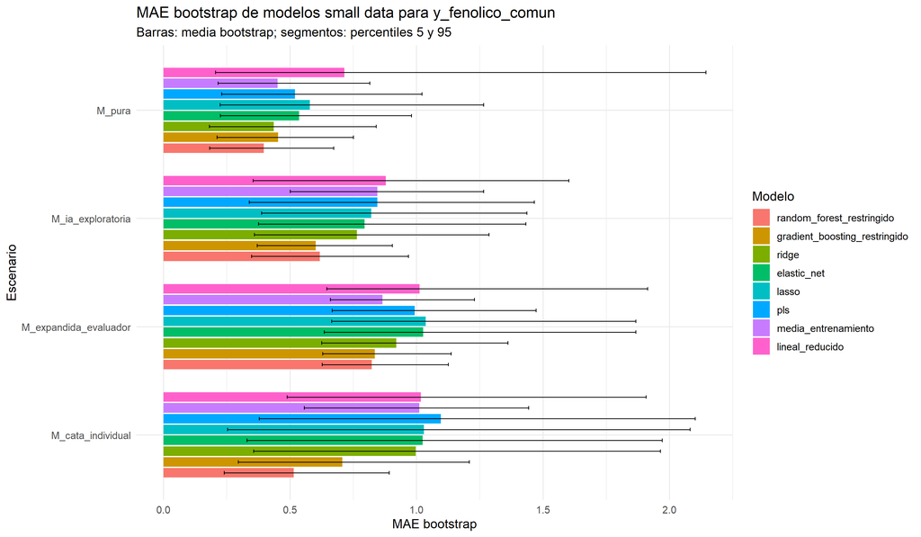

** 02_variables_estables_M_pura_y_fenolico **

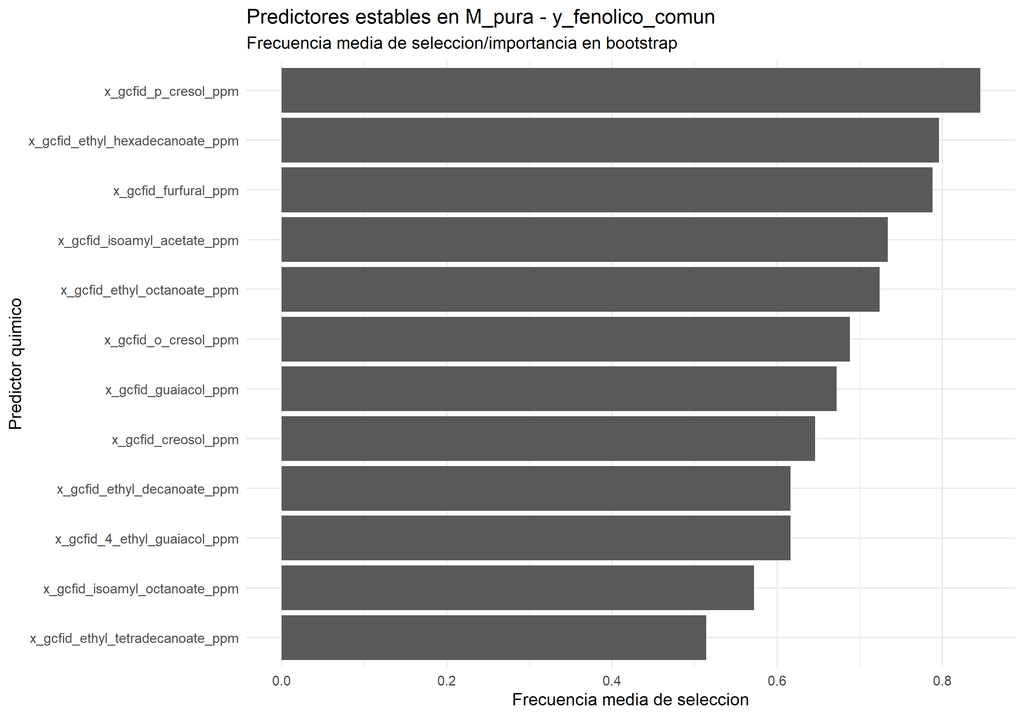

## 3.9 Sensibilidad a valores atípicos químicos

Comparación del desempeño del modelo principal (Random Forest restringido) y del modelo alternativo (Ridge) con y sin las unidades marcadas como atípicas en la etapa exploratoria (Dixon / T²-Q), para evaluar si los resultados dependen de esos puntos.

| modelo | target | version | n_bootstrap_exitosos | n_fallback_holdout | mae_media | mae_p05 | mae_p50 | mae_p95 | rmse_media | r2_media | r2_agregado | spearman_media | bias_media |
| --- | --- | --- | --- | --- | --- | --- | --- | --- | --- | --- | --- | --- | --- |
| random_forest_restringido | y_fenolico_comun | completo | 100 | 2 | 0.3958918 | 0.1815655 | 0.3676044 | 0.6724122 | 0.4584317 | 0.0336639 | 0.2472768 | 0.1964191 | 0.0979814 |
| random_forest_restringido | y_fenolico_comun | sin_outliers_eda | 100 | 4 | 0.4208031 | 0.1879150 | 0.3772325 | 0.8094814 | 0.4792065 | -0.0085386 | 0.1986525 | 0.2326574 | 0.0887750 |
| random_forest_restringido | y_frutal_comun | completo | 73 | 7 | 0.3268152 | 0.1041773 | 0.2987840 | 0.5375600 | 0.3570632 | -0.5626306 | -0.0604418 | -0.0474169 | 0.1053356 |
| random_forest_restringido | y_frutal_comun | sin_outliers_eda | 73 | 7 | 0.3268152 | 0.1041773 | 0.2987840 | 0.5375600 | 0.3570632 | -0.5626306 | -0.0604418 | -0.0474169 | 0.1053356 |
| ridge | y_fenolico_comun | completo | 100 | 2 | 0.4360456 | 0.1807816 | 0.3915527 | 0.8397778 | 0.5140877 | -0.5122354 | -0.1401207 | 0.2162869 | 0.0510778 |
| ridge | y_fenolico_comun | sin_outliers_eda | 100 | 4 | 0.5609756 | 0.1762063 | 0.5457201 | 1.2118994 | 0.6457457 | -1.9052405 | -0.8243634 | 0.1255327 | -0.0298783 |
| ridge | y_frutal_comun | completo | 73 | 7 | 0.3866299 | 0.1418590 | 0.4066026 | 0.5923895 | 0.4188874 | -3.8868545 | -0.5256405 | -0.4752766 | 0.0889480 |
| ridge | y_frutal_comun | sin_outliers_eda | 73 | 7 | 0.3866299 | 0.1418590 | 0.4066026 | 0.5923895 | 0.4188874 | -3.8868545 | -0.5256405 | -0.4752766 | 0.0889480 |

** 01_comparacion_mae_completo_vs_sin_outliers **

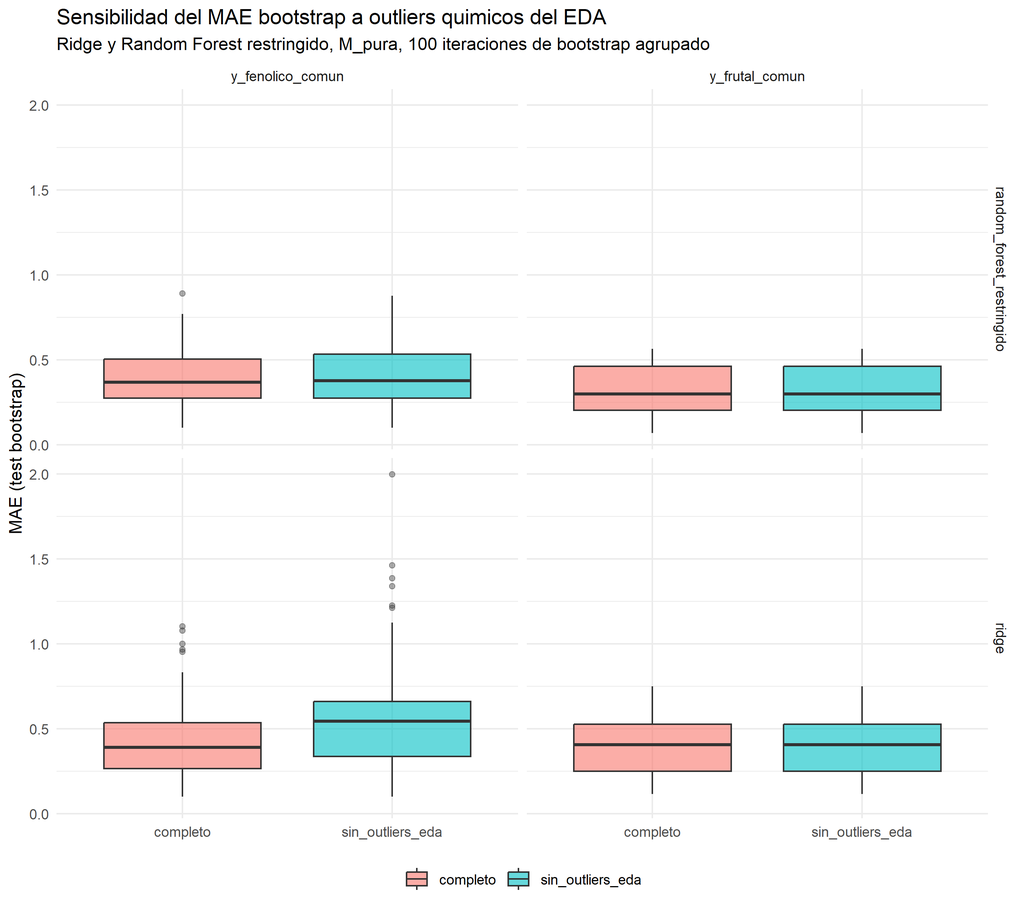

## 3.10 Sensibilidad a la imputación de variables GC-MS

| modelo | target | version | n_bootstrap_exitosos | n_fallback_holdout | mae_media | mae_p05 | mae_p50 | mae_p95 | rmse_media | r2_media | r2_agregado | spearman_media | bias_media |
| --- | --- | --- | --- | --- | --- | --- | --- | --- | --- | --- | --- | --- | --- |
| random_forest_restringido | y_fenolico_comun | completo | 100 | 2 | 0.3996298 | 0.1934218 | 0.3680135 | 0.7131985 | 0.4598523 | 0.0485609 | 0.2571073 | 0.1785079 | 0.0761444 |
| random_forest_restringido | y_fenolico_comun | sin_gcms | 100 | 2 | 0.3958918 | 0.1815655 | 0.3676044 | 0.6724122 | 0.4584317 | 0.0336639 | 0.2472768 | 0.1964191 | 0.0979814 |
| random_forest_restringido | y_frutal_comun | completo | 93 | 7 | 0.3416579 | 0.1248048 | 0.3355850 | 0.5519220 | 0.3736764 | -0.7127738 | -0.1237970 | -0.1615800 | 0.1055819 |
| random_forest_restringido | y_frutal_comun | sin_gcms | 73 | 7 | 0.3268152 | 0.1041773 | 0.2987840 | 0.5375600 | 0.3570632 | -0.5626306 | -0.0604418 | -0.0474169 | 0.1053356 |
| ridge | y_fenolico_comun | completo | 100 | 2 | 0.4519752 | 0.2259756 | 0.4012777 | 0.8691603 | 0.5310297 | -0.6150746 | -0.1751346 | 0.1940940 | 0.0625856 |
| ridge | y_fenolico_comun | sin_gcms | 100 | 2 | 0.4360456 | 0.1807816 | 0.3915527 | 0.8397778 | 0.5140877 | -0.5122354 | -0.1401207 | 0.2162869 | 0.0510778 |
| ridge | y_frutal_comun | completo | 95 | 7 | 0.3680085 | 0.1477014 | 0.3500000 | 0.5815429 | 0.4043811 | -2.8376917 | -0.3212465 | -0.4965220 | 0.0998351 |
| ridge | y_frutal_comun | sin_gcms | 73 | 7 | 0.3866299 | 0.1418590 | 0.4066026 | 0.5923895 | 0.4188874 | -3.8868545 | -0.5256405 | -0.4752766 | 0.0889480 |

| modelo | target | mae_media_completo | mae_media_sin_gcms | rmse_media_completo | rmse_media_sin_gcms | r2_media_completo | r2_media_sin_gcms | spearman_media_completo | spearman_media_sin_gcms | diferencia_mae | diferencia_mae_pct | diferencia_r2 | lectura |
| --- | --- | --- | --- | --- | --- | --- | --- | --- | --- | --- | --- | --- | --- |
| random_forest_restringido | y_fenolico_comun | 0.400 | 0.396 | 0.460 | 0.458 | 0.049 | 0.034 | 0.179 | 0.196 | -0.004 | -0.9 | -0.015 | robusto: el MAE cambia menos de 10% al quitar las variables GC-MS |
| random_forest_restringido | y_frutal_comun | 0.342 | 0.327 | 0.374 | 0.357 | -0.713 | -0.563 | -0.162 | -0.047 | -0.015 | -4.3 | 0.150 | robusto: el MAE cambia menos de 10% al quitar las variables GC-MS |
| ridge | y_fenolico_comun | 0.452 | 0.436 | 0.531 | 0.514 | -0.615 | -0.512 | 0.194 | 0.216 | -0.016 | -3.5 | 0.103 | robusto: el MAE cambia menos de 10% al quitar las variables GC-MS |
| ridge | y_frutal_comun | 0.368 | 0.387 | 0.404 | 0.419 | -2.838 | -3.887 | -0.497 | -0.475 | 0.019 | 5.1 | -1.049 | robusto: el MAE cambia menos de 10% al quitar las variables GC-MS |

** 01_comparacion_mae_completo_vs_sin_gcms **

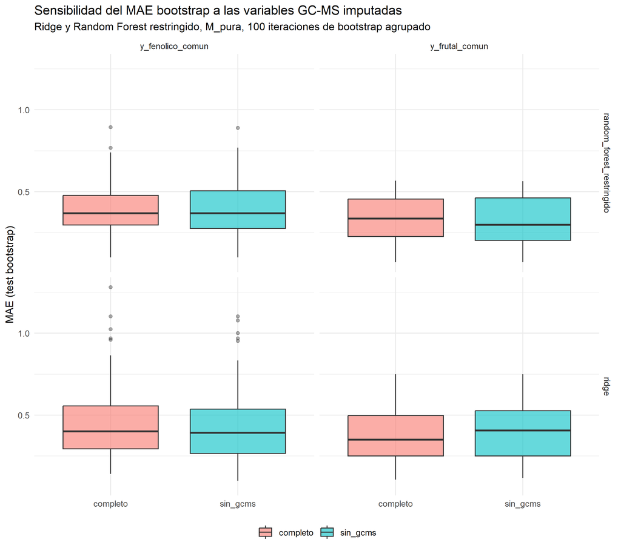

## 3.11 Sensibilidad a las muestras comerciales

De las 10 muestras independientes de `M_pura`, 2 son whiskies comerciales importados (Dalwhinnie y Caol Ila) y 8 son experimentales chilenas. Esas dos muestras ocupan la parte alta del rango del target: Caol Ila es, con diferencia, la de mayor carácter fenólico percibido (3.38 de promedio) y Dalwhinnie queda entre las más altas (2.57), frente a un rango de 1.80 a 2.60 en las ocho restantes. Para saber si el modelo está capturando una relación química-sensorial dentro del whisky chileno o si se apoya en el contraste entre muestras importadas y experimentales, se repitió el bootstrap agrupado (100 iteraciones, Random Forest restringido y Ridge) excluyendo esas 2 muestras: 24 unidades analíticas y 8 muestras independientes.

| modelo | target | version | n_bootstrap_exitosos | n_fallback_holdout | mae_media | mae_p05 | mae_p50 | mae_p95 | rmse_media | r2_media | r2_agregado | r2_pct_positivo | spearman_media | bias_media |
| --- | --- | --- | --- | --- | --- | --- | --- | --- | --- | --- | --- | --- | --- | --- |
| random_forest_restringido | y_fenolico_comun | completo | 100 | 2 | 0.396 | 0.182 | 0.368 | 0.672 | 0.458 | 0.034 | 0.247 | 68 | 0.196 | 0.098 |
| random_forest_restringido | y_fenolico_comun | sin_comerciales | 100 | 3 | 0.235 | 0.121 | 0.219 | 0.400 | 0.273 | -0.441 | -0.147 | 33 | -0.043 | 0.060 |
| ridge | y_fenolico_comun | completo | 100 | 2 | 0.436 | 0.181 | 0.392 | 0.840 | 0.514 | -0.512 | -0.140 | 52 | 0.216 | 0.051 |
| ridge | y_fenolico_comun | sin_comerciales | 100 | 3 | 0.389 | 0.138 | 0.266 | 0.814 | 0.434 | -7.004 | -8.473 | 22 | -0.133 | 0.177 |

| modelo | target | mae_media_completo | mae_media_sin_comerciales | r2_agregado_completo | r2_agregado_sin_comerciales | diferencia_mae | diferencia_mae_pct | diferencia_r2_agregado | lectura |
| --- | --- | --- | --- | --- | --- | --- | --- | --- | --- |
| random_forest_restringido | y_fenolico_comun | 0.396 | 0.235 | 0.247 | -0.147 | -0.161 | -40.6 | -0.394 | senal_no_sobrevive: R2 agregado deja de ser positivo sin las muestras comerciales |
| ridge | y_fenolico_comun | 0.436 | 0.389 | -0.140 | -8.473 | -0.047 | -10.8 | -8.333 | senal_no_sobrevive: R2 agregado deja de ser positivo sin las muestras comerciales |

** 01_comparacion_mae_completo_vs_sin_comerciales **

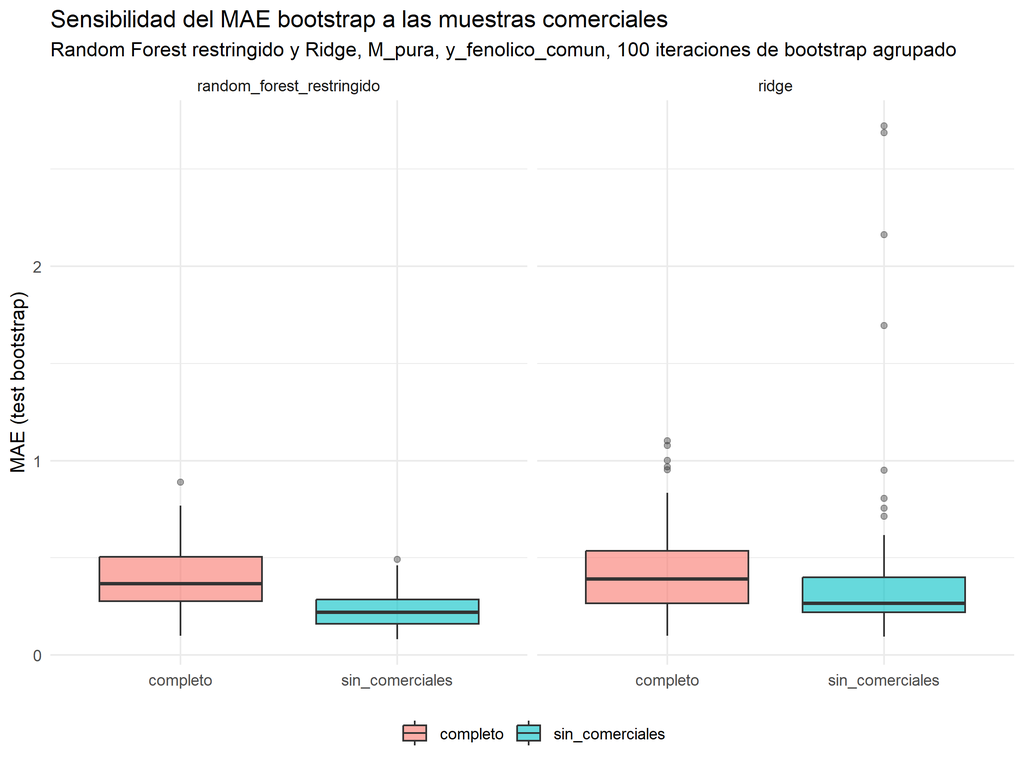

Este es el análisis de sensibilidad más exigente de los cinco y el resultado es negativo: **la señal no sobrevive**. En Random Forest restringido el MAE incluso baja (de 0.396 a 0.235, un 40.6% menos), pero el R² agregado pasa de 0.247 a **-0.147**, y el porcentaje de iteraciones con R² positivo cae de 68% a 33%. Ridge se comporta igual o peor (R² agregado de -0.140 a -8.47).

Conviene leer las dos métricas juntas, porque apuntan en direcciones opuestas por una razón entendible: al quitar las dos muestras más ahumadas, el target se vuelve mucho más homogéneo, así que los errores absolutos se achican (baja el MAE) pero también se achica la varianza que había que explicar. El R² se mide contra la media del pliegue de entrenamiento, y con un rango estrecho el modelo deja de superar a esa media. Dicho de otro modo: dentro de las 8 muestras chilenas, el modelo **no predice mejor que decir “el promedio”**.

La conclusión honesta es que buena parte de la capacidad predictiva de `M_pura` descansa en el contraste entre las muestras comerciales ahumadas y las experimentales. Las variables identificadas como prioritarias (fenoles volátiles por GC-FID) siguen siendo químicamente coherentes con lo que distingue a esas muestras, pero este resultado impide afirmar que el modelo capture una relación química-sensorial fina dentro del whisky chileno. Con 8 muestras independientes la incertidumbre de esta versión es además mayor que la del escenario completo, así que tampoco se puede concluir lo contrario con seguridad: lo que corresponde es declarar el límite.

## 3.12 Sensibilidad a la imputación de variables GC-FID

El análisis anterior sobre GC-MS se complementa con el caso inverso: 8 de las 34 unidades de `M_pura` no tienen GC-FID real y reciben todos sus predictores GC-FID por imputación de mediana. Para comprobar que los resultados no se apoyan en esas filas completamente imputadas, se repitió el mismo bootstrap excluyéndolas: 26 unidades analíticas y 6 muestras independientes.

| modelo | target | version | n_bootstrap_exitosos | n_fallback_holdout | mae_media | mae_p05 | mae_p50 | mae_p95 | rmse_media | r2_media | r2_agregado | r2_pct_positivo | spearman_media | bias_media |
| --- | --- | --- | --- | --- | --- | --- | --- | --- | --- | --- | --- | --- | --- | --- |
| random_forest_restringido | y_fenolico_comun | completo | 100 | 2 | 0.396 | 0.182 | 0.368 | 0.672 | 0.458 | 0.034 | 0.247 | 68 | 0.196 | 0.098 |
| random_forest_restringido | y_fenolico_comun | sin_imputacion_total | 100 | 24 | 0.382 | 0.179 | 0.311 | 0.894 | 0.436 | 0.093 | 0.221 | 67 | 0.351 | 0.065 |
| ridge | y_fenolico_comun | completo | 100 | 2 | 0.436 | 0.181 | 0.392 | 0.840 | 0.514 | -0.512 | -0.140 | 52 | 0.216 | 0.051 |
| ridge | y_fenolico_comun | sin_imputacion_total | 100 | 24 | 0.372 | 0.170 | 0.274 | 1.260 | 0.404 | 0.121 | 0.198 | 59 | 0.402 | -0.019 |

| modelo | target | mae_media_completo | mae_media_sin_imputacion_total | r2_agregado_completo | r2_agregado_sin_imputacion_total | diferencia_mae | diferencia_mae_pct | diferencia_r2_agregado | lectura |
| --- | --- | --- | --- | --- | --- | --- | --- | --- | --- |
| random_forest_restringido | y_fenolico_comun | 0.396 | 0.382 | 0.247 | 0.221 | -0.013 | -3.4 | -0.027 | senal_sobrevive: R2 agregado se mantiene positivo al excluir las unidades totalmente imputadas |
| ridge | y_fenolico_comun | 0.436 | 0.372 | -0.140 | 0.198 | -0.065 | -14.8 | 0.338 | senal_sobrevive: R2 agregado se mantiene positivo al excluir las unidades totalmente imputadas |

** 01_comparacion_mae_completo_vs_sin_imputacion_total **

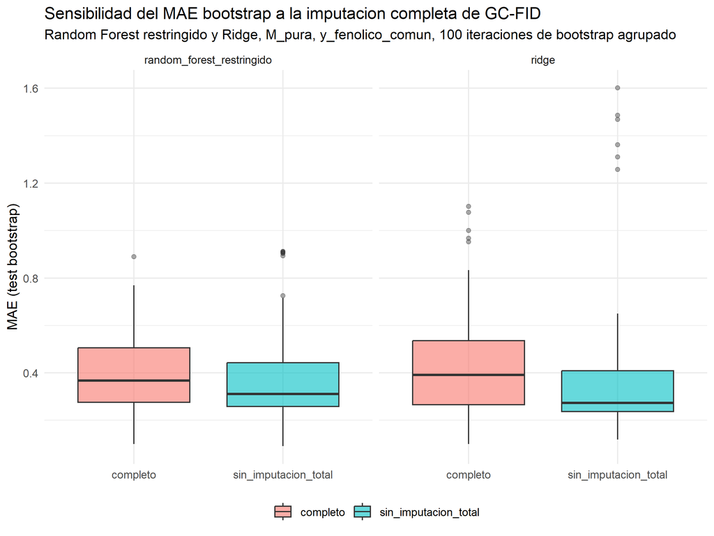

Aquí **la señal sí sobrevive**. En Random Forest restringido el MAE baja un 3.4% (0.396 a 0.382) y el R² agregado se mantiene positivo y prácticamente igual (0.247 a 0.221). Ridge incluso mejora de forma apreciable (MAE -14.8%, y su R² agregado pasa de -0.140 a 0.198). Es decir, las filas sin GC-FID real no estaban sosteniendo artificialmente el desempeño; si acaso, lo estaban diluyendo.

Un detalle metodológico que conviene no pasar por alto: al quedar solo 6 muestras independientes, el número de iteraciones que debieron recurrir a la partición de respaldo 75/25 sube de 2 a 24 de 100. La comparación sigue siendo válida, pero esa versión se apoya en un remuestreo menos rico que la completa, lo que explica su mayor dispersión (percentil 95 del MAE de 0.894 en Random Forest, frente a 0.672 en la versión completa).

## 3.13 Sensibilidad a la escala del bloque de septiembre

Las fichas de cata de septiembre de 2024 usaron una escala 1-5, mientras que el resto de los bloques usó 0-5. Como esas 9 unidades entran a `M_pura` junto con las demás, cabe preguntarse si el piso distinto introduce un artefacto. Para medirlo se reescalaron linealmente solo esas 9 filas, con `(y - 1) * 5 / 4`, y se repitió el bootstrap sobre las mismas 34 unidades.

Antes de cualquier modelo, B1, C70 y H76 son las únicas muestras evaluadas en los dos bloques, lo que permite comparar directamente el mismo whisky bajo ambas escalas:

| identificador_quimico | bloque_sensorial | y_fenolico_comun |
| --- | --- | --- |
| B1 | cata_septiembre_2024 | 2.111 |
| B1 | cata_social_enero_2025 | 2.110 |
| C70 | cata_septiembre_2024 | 2.044 |
| C70 | cata_social_enero_2025 | 1.840 |
| H76 | cata_septiembre_2024 | 2.450 |
| H76 | cata_social_enero_2025 | 1.977 |

| modelo | target | version | n_bootstrap_exitosos | n_fallback_holdout | mae_media | mae_p05 | mae_p50 | mae_p95 | rmse_media | r2_media | r2_agregado | r2_pct_positivo | spearman_media | bias_media |
| --- | --- | --- | --- | --- | --- | --- | --- | --- | --- | --- | --- | --- | --- | --- |
| random_forest_restringido | y_fenolico_comun | original | 100 | 2 | 0.396 | 0.182 | 0.368 | 0.672 | 0.458 | 0.034 | 0.247 | 68 | 0.196 | 0.098 |
| random_forest_restringido | y_fenolico_comun | reescalado_0a5 | 100 | 2 | 0.436 | 0.134 | 0.427 | 0.733 | 0.524 | 0.229 | 0.374 | 88 | 0.371 | 0.110 |
| ridge | y_fenolico_comun | original | 100 | 2 | 0.436 | 0.181 | 0.392 | 0.840 | 0.514 | -0.512 | -0.140 | 52 | 0.216 | 0.051 |
| ridge | y_fenolico_comun | reescalado_0a5 | 100 | 2 | 0.561 | 0.182 | 0.514 | 1.098 | 0.658 | -0.662 | -0.127 | 58 | 0.347 | 0.058 |

| modelo | target | mae_media_original | mae_media_reescalado_0a5 | r2_agregado_original | r2_agregado_reescalado_0a5 | diferencia_mae | diferencia_mae_pct | diferencia_r2_agregado | lectura |
| --- | --- | --- | --- | --- | --- | --- | --- | --- | --- |
| random_forest_restringido | y_fenolico_comun | 0.396 | 0.436 | 0.247 | 0.374 | 0.040 | 10.2 | 0.126 | mejora_al_reescalar |
| ridge | y_fenolico_comun | 0.436 | 0.561 | -0.140 | -0.127 | 0.124 | 28.5 | 0.013 | sin_cambio_relevante: el R2 agregado no cambia de forma apreciable al reescalar cata_septiembre_2024 |

** 01_comparacion_mae_original_vs_reescalado **

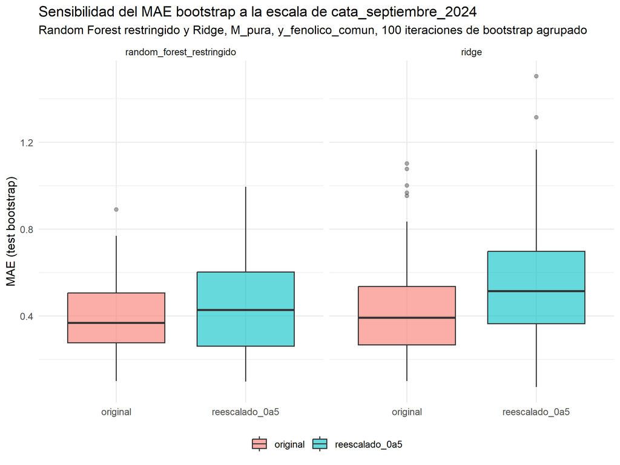

La comparación pareada muestra diferencias pequeñas y no sistemáticas entre los dos bloques (B1 prácticamente idéntico, 2.111 contra 2.110; C70 y H76 algo más altos en septiembre, 0.20 y 0.47 puntos), lo que ya sugiere que el efecto de escala no domina la señal.

En el modelamiento, el reescalado **no cambia la conclusión**. Random Forest restringido sube su MAE un 10.2% (0.396 a 0.436) pero mejora su R² agregado (0.247 a 0.374) y su porcentaje de iteraciones positivas (68% a 88%), mientras que en Ridge el R² agregado se mantiene prácticamente igual (-0.140 a -0.127). Ninguna de las dos versiones cambia de signo ni de orden de magnitud, así que el desempeño del modelo principal no es un artefacto del piso de escala del bloque de septiembre.

Dos advertencias sobre este análisis. La transformación supone que el desplazamiento de escala es puramente lineal y afecta igual a los cinco descriptores de origen, y no corrige un eventual sesgo propio del panel de ese bloque, solo el artefacto de escala declarado. Y el hecho de que el reescalado *mejore* el R² no es razón para adoptarlo como versión oficial: se mantiene la escala original declarada por cada bloque, y este análisis se reporta como verificación, no como ajuste a posteriori.

## 3.14 Sensibilidad a las muestras comerciales en la cata individual

Este es el análogo del análisis de muestras comerciales, pero aplicado a `M_cata_individual` (52 unidades, 16 muestras independientes, 26 predictores al sumar las variables fermentativas JU) en vez de `M_pura`. La pregunta es la misma: el R² notoriamente más alto de este escenario, ¿depende también del contraste entre whiskies comerciales y experimentales?

| modelo | target | version | n_bootstrap_exitosos | n_fallback_holdout | mae_media | mae_p05 | mae_p50 | mae_p95 | rmse_media | r2_media | r2_agregado | r2_pct_positivo | spearman_media | bias_media |
| --- | --- | --- | --- | --- | --- | --- | --- | --- | --- | --- | --- | --- | --- | --- |
| random_forest_restringido | y_fenolico_comun | completo | 100 | 0 | 0.515 | 0.239 | 0.480 | 0.891 | 0.647 | 0.660 | 0.647 | 100 | 0.689 | -0.026 |
| random_forest_restringido | y_fenolico_comun | sin_comerciales | 100 | 0 | 0.392 | 0.163 | 0.375 | 0.729 | 0.507 | 0.673 | 0.706 | 98 | 0.787 | 0.006 |
| ridge | y_fenolico_comun | completo | 100 | 0 | 0.997 | 0.356 | 0.919 | 1.963 | 1.185 | -0.434 | -0.248 | 52 | 0.404 | -0.089 |
| ridge | y_fenolico_comun | sin_comerciales | 100 | 0 | 0.943 | 0.310 | 0.843 | 1.961 | 1.122 | -0.886 | -0.693 | 56 | 0.320 | 0.022 |

| modelo | target | mae_media_completo | mae_media_sin_comerciales | r2_agregado_completo | r2_agregado_sin_comerciales | diferencia_mae | diferencia_mae_pct | diferencia_r2_agregado | lectura |
| --- | --- | --- | --- | --- | --- | --- | --- | --- | --- |
| random_forest_restringido | y_fenolico_comun | 0.515 | 0.392 | 0.647 | 0.706 | -0.123 | -23.8 | 0.059 | senal_sobrevive: R2 agregado se mantiene positivo sin las muestras comerciales |
| ridge | y_fenolico_comun | 0.997 | 0.943 | -0.248 | -0.693 | -0.054 | -5.4 | -0.445 | senal_no_sobrevive: R2 agregado deja de ser positivo sin las muestras comerciales |

A diferencia de `M_pura`, aquí **la señal sí sobrevive** en el modelo principal: al excluir Dalwhinnie y Caol Ila, Random Forest restringido baja su MAE un 23.8% (0.515 a 0.392) y su R² agregado incluso sube (0.647 a 0.706), manteniendo un 98% de iteraciones con R² positivo. Ridge, en cambio, no sobrevive (R² agregado de -0.248 a -0.693), lo que refuerza que el desempeño de este escenario proviene de una estructura no lineal y no de una relación lineal simple.

Esto no convierte a `M_cata_individual` en el escenario recomendado. Su ventaja se explica por dos condiciones que no son generalizables: un único catador, lo que elimina la variabilidad entre evaluadores que sí está presente en `M_pura`, y el doble de predictores. Lo que este análisis aporta es más acotado: muestra que la limitación detectada en `M_pura` (depender del contraste comercial-experimental) no es inevitable, y que con una fuente sensorial internamente consistente la señal química se sostiene incluso dentro del conjunto de muestras chilenas.

# 4 - RESULTADOS FINALES

## 4.1 Objetivo de esta parte

Esta parte integra los resultados de las etapas anteriores: qué variables explican mejor la calidad sensorial fenólica, cómo se comparan los escenarios de modelamiento entre sí, qué tan robustos son los resultados frente a valores atípicos, y qué conclusiones se pueden sostener con la evidencia disponible.

Un análisis más detallado en formato de guía de defensa (con preguntas anticipadas de comisión) está disponible en `outputs/modelamiento/analisis_finales/resultados_finales_y_guia_defensa.pdf`.

## 4.2 Interpretabilidad de variables

Consenso de importancia de variables entre los distintos modelos candidatos, para `y_fenolico_comun` en el escenario principal (`M_pura`).

| escenario | target | predictor | predictor_limpio | tecnica | familia_quimica | coherencia_target | n_modelos_con_variable | modelos_que_la_reportan | frecuencia_media | frecuencia_max | importancia_norm_media | importancia_norm_max | n_bootstrap_total_modelos | justificacion_quimica | importancia_norm_minmax | score_combinado | estabilidad_consenso | prioridad_tesis | ranking_consenso |
| --- | --- | --- | --- | --- | --- | --- | --- | --- | --- | --- | --- | --- | --- | --- | --- | --- | --- | --- | --- |
| M_cata_individual | y_fenolico_comun | x_gcfid_o_cresol_ppm | gcfid o cresol ppm | GC-FID | fenoles_volatiles | alta_directa | 4 | elastic_net; lasso; random_forest_restringido; ridge | 0.7425000 | 0.89 | 33.0734555 | 52.4512040 | 297 | Coherente: cresoles, guaiacol u otros fenoles volatiles se relacionan directamente con notas fenolicas/ahumadas. | 0.9075991 | 0.8250495 | alta | prioritaria | 1 |
| M_cata_individual | y_fenolico_comun | x_gcfid_4_ethyl_guaiacol_ppm | gcfid 4 ethyl guaiacol ppm | GC-FID | fenoles_volatiles | alta_directa | 4 | elastic_net; lasso; random_forest_restringido; ridge | 0.5825000 | 0.75 | 36.4195744 | 49.2541504 | 233 | Coherente: cresoles, guaiacol u otros fenoles volatiles se relacionan directamente con notas fenolicas/ahumadas. | 1.0000000 | 0.7912500 | media | apoyo_interpretativo | 2 |
| M_cata_individual | y_fenolico_comun | x_ju_maltose_consumption_g_l | ju maltose consumption g l | JU | fermentacion_indirecta | media_indirecta | 4 | elastic_net; lasso; random_forest_restringido; ridge | 0.7800000 | 0.92 | 8.5928851 | 27.6969265 | 312 | Interpretacion indirecta: puede capturar diferencias de fermentacion o bloque analitico, no causalidad fenolica directa. | 0.2315838 | 0.5057919 | alta | apoyo_interpretativo | 3 |
| M_cata_individual | y_fenolico_comun | x_ju_final_co2_loss_g_l | ju final co2 loss g l | JU | fermentacion_indirecta | media_indirecta | 4 | elastic_net; lasso; random_forest_restringido; ridge | 0.7350000 | 0.93 | 8.3012084 | 30.6334523 | 294 | Interpretacion indirecta: puede capturar diferencias de fermentacion o bloque analitico, no causalidad fenolica directa. | 0.2235293 | 0.4792647 | alta | apoyo_interpretativo | 4 |
| M_cata_individual | y_fenolico_comun | x_ju_ethanol_production_g_l | ju ethanol production g l | JU | fermentacion_indirecta | media_indirecta | 4 | elastic_net; lasso; random_forest_restringido; ridge | 0.6575000 | 0.92 | 10.1185578 | 25.9768955 | 263 | Interpretacion indirecta: puede capturar diferencias de fermentacion o bloque analitico, no causalidad fenolica directa. | 0.2737143 | 0.4656071 | media | apoyo_interpretativo | 5 |
| M_cata_individual | y_fenolico_comun | x_gcfid_guaiacol_ppm | gcfid guaiacol ppm | GC-FID | fenoles_volatiles | alta_directa | 4 | elastic_net; lasso; random_forest_restringido; ridge | 0.5825000 | 0.76 | 10.7241071 | 22.1522832 | 233 | Coherente: cresoles, guaiacol u otros fenoles volatiles se relacionan directamente con notas fenolicas/ahumadas. | 0.2904361 | 0.4364681 | media | apoyo_interpretativo | 6 |
| M_cata_individual | y_fenolico_comun | x_ju_ethyl_myristate_ppm | ju ethyl myristate ppm | JU | esteres | media_contextual | 4 | elastic_net; lasso; random_forest_restringido; ridge | 0.1575000 | 0.28 | 27.7608476 | 42.6518348 | 63 | Interpretacion contextual: los esteres pueden separar perfiles de muestra, pero no son evidencia fenolica directa. | 0.7608948 | 0.4591974 | baja | baja_prioridad | 7 |
| M_cata_individual | y_fenolico_comun | x_gcfid_p_cresol_ppm | gcfid p cresol ppm | GC-FID | fenoles_volatiles | alta_directa | 4 | elastic_net; lasso; random_forest_restringido; ridge | 0.4725000 | 0.73 | 9.1988862 | 15.0046186 | 189 | Coherente: cresoles, guaiacol u otros fenoles volatiles se relacionan directamente con notas fenolicas/ahumadas. | 0.2483181 | 0.3604091 | baja_media | baja_prioridad | 8 |
| M_cata_individual | y_fenolico_comun | x_ju_ferulic_acid_conversion_index_faci_percent | ju ferulic acid conversion index faci percent | JU | fermentacion_indirecta | media_indirecta | 4 | elastic_net; lasso; random_forest_restringido; ridge | 0.3925000 | 0.47 | 7.6455039 | 24.0620768 | 157 | Interpretacion indirecta: puede capturar diferencias de fermentacion o bloque analitico, no causalidad fenolica directa. | 0.2054224 | 0.2989612 | baja_media | baja_prioridad | 9 |
| M_cata_individual | y_fenolico_comun | x_gcfid_furfural_ppm | gcfid furfural ppm | GC-FID | aldehidos_furanicos | baja_contextual | 4 | elastic_net; lasso; random_forest_restringido; ridge | 0.4825000 | 0.75 | 3.5032335 | 4.7766690 | 193 | Debe interpretarse como asociacion estadistica exploratoria y contrastarse con literatura/criterio experto. | 0.0910363 | 0.2867682 | baja_media | baja_prioridad | 10 |
| M_cata_individual | y_fenolico_comun | x_gcfid_isoamyl_acetate_ppm | gcfid isoamyl acetate ppm | GC-FID | esteres | media_contextual | 4 | elastic_net; lasso; random_forest_restringido; ridge | 0.4675000 | 0.73 | 2.7021635 | 5.1779244 | 187 | Interpretacion contextual: los esteres pueden separar perfiles de muestra, pero no son evidencia fenolica directa. | 0.0689153 | 0.2682076 | baja_media | baja_prioridad | 11 |
| M_cata_individual | y_fenolico_comun | x_gcfid_ethyl_octanoate_ppm | gcfid ethyl octanoate ppm | GC-FID | esteres | media_contextual | 4 | elastic_net; lasso; random_forest_restringido; ridge | 0.4725000 | 0.77 | 1.4339527 | 5.4450157 | 189 | Interpretacion contextual: los esteres pueden separar perfiles de muestra, pero no son evidencia fenolica directa. | 0.0338944 | 0.2531972 | baja_media | baja_prioridad | 12 |
| M_cata_individual | y_fenolico_comun | x_gcfid_creosol_ppm | gcfid creosol ppm | GC-FID | otros | no_prioritaria | 4 | elastic_net; lasso; random_forest_restringido; ridge | 0.2950000 | 0.54 | 7.7040382 | 13.3802139 | 118 | Debe interpretarse como asociacion estadistica exploratoria y contrastarse con literatura/criterio experto. | 0.2070388 | 0.2510194 | baja | baja_prioridad | 13 |
| M_cata_individual | y_fenolico_comun | x_ju_ethyl_hexadecanoate_ppm | ju ethyl hexadecanoate ppm | JU | esteres | media_contextual | 4 | elastic_net; lasso; random_forest_restringido; ridge | 0.3250000 | 0.50 | 5.8802387 | 9.8155762 | 130 | Interpretacion contextual: los esteres pueden separar perfiles de muestra, pero no son evidencia fenolica directa. | 0.1566758 | 0.2408379 | baja_media | baja_prioridad | 14 |
| M_cata_individual | y_fenolico_comun | x_ju_p_cresol_ppm | ju p cresol ppm | JU | fenoles_volatiles | alta_directa | 4 | elastic_net; lasso; random_forest_restringido; ridge | 0.0850000 | 0.14 | 13.5402708 | 18.9566459 | 34 | Coherente: cresoles, guaiacol u otros fenoles volatiles se relacionan directamente con notas fenolicas/ahumadas. | 0.3682027 | 0.2266013 | baja | baja_prioridad | 15 |
| M_cata_individual | y_fenolico_comun | x_gcfid_ethyl_dodecanoate_ppm | gcfid ethyl dodecanoate ppm | GC-FID | esteres | media_contextual | 4 | elastic_net; lasso; random_forest_restringido; ridge | 0.3800000 | 0.58 | 2.7804515 | 5.7522173 | 152 | Interpretacion contextual: los esteres pueden separar perfiles de muestra, pero no son evidencia fenolica directa. | 0.0710771 | 0.2255386 | baja_media | baja_prioridad | 16 |
| M_cata_individual | y_fenolico_comun | x_gcfid_ethyl_hexadecanoate_ppm | gcfid ethyl hexadecanoate ppm | GC-FID | esteres | media_contextual | 4 | elastic_net; lasso; random_forest_restringido; ridge | 0.4050000 | 0.66 | 1.5969185 | 5.9679304 | 162 | Interpretacion contextual: los esteres pueden separar perfiles de muestra, pero no son evidencia fenolica directa. | 0.0383946 | 0.2216973 | baja_media | baja_prioridad | 17 |
| M_cata_individual | y_fenolico_comun | x_ju_isoamyl_octanoate_ppm | ju isoamyl octanoate ppm | JU | esteres | media_contextual | 4 | elastic_net; lasso; random_forest_restringido; ridge | 0.1500000 | 0.25 | 9.8253747 | 17.1377269 | 60 | Interpretacion contextual: los esteres pueden separar perfiles de muestra, pero no son evidencia fenolica directa. | 0.2656182 | 0.2078091 | baja | baja_prioridad | 18 |
| M_cata_individual | y_fenolico_comun | x_gcfid_ethyl_decanoate_ppm | gcfid ethyl decanoate ppm | GC-FID | esteres | media_contextual | 4 | elastic_net; lasso; random_forest_restringido; ridge | 0.3400000 | 0.51 | 1.5250151 | 5.0391935 | 136 | Interpretacion contextual: los esteres pueden separar perfiles de muestra, pero no son evidencia fenolica directa. | 0.0364091 | 0.1882045 | baja_media | baja_prioridad | 19 |
| M_cata_individual | y_fenolico_comun | x_ju_ethyl_decanoate_ppm | ju ethyl decanoate ppm | JU | esteres | media_contextual | 4 | elastic_net; lasso; random_forest_restringido; ridge | 0.2650000 | 0.41 | 3.9888262 | 8.7990521 | 106 | Interpretacion contextual: los esteres pueden separar perfiles de muestra, pero no son evidencia fenolica directa. | 0.1044456 | 0.1847228 | baja | baja_prioridad | 20 |
| M_cata_individual | y_fenolico_comun | x_ju_o_cresol_ppm | ju o cresol ppm | JU | fenoles_volatiles | alta_directa | 4 | elastic_net; lasso; random_forest_restringido; ridge | 0.3250000 | 0.50 | 1.3700916 | 3.2570117 | 130 | Coherente: cresoles, guaiacol u otros fenoles volatiles se relacionan directamente con notas fenolicas/ahumadas. | 0.0321310 | 0.1785655 | baja_media | baja_prioridad | 21 |
| M_cata_individual | y_fenolico_comun | x_ju_ethyl_dodecanoate_ppm | ju ethyl dodecanoate ppm | JU | esteres | media_contextual | 4 | elastic_net; lasso; random_forest_restringido; ridge | 0.1450000 | 0.27 | 7.5598150 | 11.7058582 | 58 | Interpretacion contextual: los esteres pueden separar perfiles de muestra, pero no son evidencia fenolica directa. | 0.2030562 | 0.1740281 | baja | baja_prioridad | 22 |
| M_cata_individual | y_fenolico_comun | x_gcfid_isoamyl_octanoate_ppm | gcfid isoamyl octanoate ppm | GC-FID | esteres | media_contextual | 4 | elastic_net; lasso; random_forest_restringido; ridge | 0.2525000 | 0.45 | 3.3817534 | 4.9683191 | 101 | Interpretacion contextual: los esteres pueden separar perfiles de muestra, pero no son evidencia fenolica directa. | 0.0876817 | 0.1700909 | baja | baja_prioridad | 23 |
| M_cata_individual | y_fenolico_comun | x_gcfid_ethyl_tetradecanoate_ppm | gcfid ethyl tetradecanoate ppm | GC-FID | esteres | media_contextual | 4 | elastic_net; lasso; random_forest_restringido; ridge | 0.2225000 | 0.43 | 4.3151830 | 8.9334132 | 89 | Interpretacion contextual: los esteres pueden separar perfiles de muestra, pero no son evidencia fenolica directa. | 0.1134578 | 0.1679789 | baja | baja_prioridad | 24 |
| M_cata_individual | y_fenolico_comun | x_ju_ethyl_octanoate_ppm | ju ethyl octanoate ppm | JU | esteres | media_contextual | 4 | elastic_net; lasso; random_forest_restringido; ridge | 0.3075000 | 0.49 | 0.2065321 | 0.7259245 | 123 | Interpretacion contextual: los esteres pueden separar perfiles de muestra, pero no son evidencia fenolica directa. | 0.0000000 | 0.1537500 | baja_media | baja_prioridad | 25 |
| M_cata_individual | y_fenolico_comun | x_ju_isoamyl_acetate_ppm | ju isoamyl acetate ppm | JU | esteres | media_contextual | 4 | elastic_net; lasso; random_forest_restringido; ridge | 0.1175000 | 0.20 | 3.7354301 | 9.8238089 | 47 | Interpretacion contextual: los esteres pueden separar perfiles de muestra, pero no son evidencia fenolica directa. | 0.0974483 | 0.1074741 | baja | baja_prioridad | 26 |
| M_cata_individual | y_frutal_comun | x_gcfid_p_cresol_ppm | gcfid p cresol ppm | GC-FID | fenoles_volatiles | baja_no_directa | 4 | elastic_net; lasso; random_forest_restringido; ridge | 0.6170650 | 1.00 | 53.1611288 | 70.6167271 | 216 | Debe interpretarse como asociacion estadistica exploratoria y contrastarse con literatura/criterio experto. | 1.0000000 | 0.8085325 | media | exploratoria_target_secundario | 1 |
| M_cata_individual | y_frutal_comun | x_gcfid_isoamyl_octanoate_ppm | gcfid isoamyl octanoate ppm | GC-FID | esteres | alta_directa | 4 | elastic_net; lasso; random_forest_restringido; ridge | 0.7395507 | 1.00 | 27.4837703 | 45.5301811 | 259 | Coherente: los esteres suelen asociarse a notas frutales, florales y fermentativas. | 0.4821549 | 0.6108528 | alta | exploratoria_target_secundario | 2 |
| M_cata_individual | y_frutal_comun | x_gcfid_isoamyl_acetate_ppm | gcfid isoamyl acetate ppm | GC-FID | esteres | alta_directa | 4 | elastic_net; lasso; random_forest_restringido; ridge | 0.7281217 | 1.00 | 22.3208725 | 58.0844243 | 255 | Coherente: los esteres suelen asociarse a notas frutales, florales y fermentativas. | 0.3780327 | 0.5530772 | alta | exploratoria_target_secundario | 3 |
| M_cata_individual | y_frutal_comun | x_gcfid_creosol_ppm | gcfid creosol ppm | GC-FID | otros | no_prioritaria | 4 | elastic_net; lasso; random_forest_restringido; ridge | 0.6084770 | 1.00 | 24.5691979 | 47.1754749 | 213 | Debe interpretarse como asociacion estadistica exploratoria y contrastarse con literatura/criterio experto. | 0.4233756 | 0.5159263 | media | exploratoria_target_secundario | 4 |

[output cut: 57 more lines]